# **Tema:** Grupo 3: Malha Aérea e Frota Brasileira **Relatório:** Análise da Operação Aérea Brasileira Atrasos, cancelamentos, malha, capacidade e modelagem preditiva

Professores:** Prof. Paulo Cilas Marques Filho Prof. Auxiliar Gabriela Kurzweil Magini

Integrantes:** Hicham Munir Tayfour – hichamt@al.insper.edu.br Laura Borri Magro – laurabm1@al.insper.edu.br Pedro Henrique Lima Zimmermann – pedrohlz@al.insper.edu.br Maria Eduarda Mesquita Netto de Faria – mariaemnf@al.insper.edu.br

São Paulo – 25/05/2026

# 1 Introdução

O transporte aéreo constitui uma infraestrutura crítica para a integração econômica e territorial do Brasil. Sua eficiência operacional afeta diretamente passageiros, companhias aéreas e a logística nacional. Atrasos e cancelamentos não representam apenas inconvenientes individuais, pois seus efeitos se estendem pela malha aérea, comprometem conexões, elevam custos operacionais e revelam gargalos estruturais em aeroportos, rotas e frota.

Este relatório analisa a operação aérea brasileira em 2023 a partir de microdados públicos da Agência Nacional de Aviação Civil (ANAC), complementados por malhas geográficas do IBGE, via pacote `geobr`, e do Natural Earth.

O objetivo central do trabalho é diagnosticar o desempenho operacional da aviação brasileira em 2023 a partir de dois desfechos distintos e complementares: o atraso relevante de chegada, definido como atraso superior a 15 minutos e calculado apenas entre voos realizados, e o cancelamento, identificado pela situação do voo e analisado sobre toda a base. A separação metodológica desses desfechos é uma decisão central do trabalho, pois eles medem fenômenos diferentes. Enquanto o atraso representa a piora de um voo concluído, o cancelamento corresponde à não realização da viagem.

Em primeiro lugar, analisamos como atrasos e cancelamentos variam entre companhias, aeroportos, rotas e turnos. Em seguida, examinamos o papel da sazonalidade mensal e do acúmulo de atrasos ao longo do dia operacional. Também avaliamos se a centralidade dos aeroportos na malha aérea, especialmente no caso dos hubs, e a localização geográfica ajudam a explicar diferenças de desempenho. Além disso, consideramos associações entre capacidade, distância, perfil de frota e resultados operacionais.

Por fim, o trabalho incorpora métodos de aprendizado de máquina com dois propósitos complementares. Um modelo supervisionado de Random Forest é utilizado para avaliar a capacidade de previsão de atrasos relevantes e identificar os fatores mais associados a esse desfecho. Além disso, é gerado um agrupamento por K-Means para classificar aeroportos segundo perfis operacionais semelhantes. As bases utilizadas, suas chaves de integração e principais limitações são documentadas na seção de diagnóstico.

# 2 Bibliotecas

```r
library(rnaturalearthdata)
library(rnaturalearth)
library(tidymodels)
library(tidyverse)
library(labelled)
library(gtExtras)
library(stringi)
library(scales)
library(arrow)
library(geobr)
library(gt)
library(sf)
library(lubridate)
library(showtext)
library(systemfonts)
library(geosphere)

set.seed(42)
```

# 3 Funções Gráficas The Economist

```r
## Definição do tibble de cores

econ_colors_tbl <- tibble::tribble(
  ~category,           ~color_name,    ~hex,
  "branding",          "econ_red",     "#E3120B",
  "main",              "data_red",     "#DB444B",
  "main",              "blue1",        "#006BA2",
  "main",              "blue2",        "#3EBCD2",
  "main",              "green",        "#379A8B",
  "main",              "yellow",       "#EBB434",
  "main",              "olive",        "#B4BA39",
  "main",              "purple",       "#9A607F",
  "main",              "gold",         "#D1B07C",
  "main",              "grey",         "#758D99",
  "text",              "base_text",    "#3F5661",
  "text",              "red_text",     "#CC334C",
  "text",              "blue2_text",   "#0097A7",
  "secondary",         "mustard",      "#E6B83C",
  "secondary",         "burgundy",     "#A63D57",
  "secondary",         "mauve",        "#B48A9B",
  "secondary",         "teal",         "#008080",
  "secondary",         "aqua",         "#6FC7C7",
  "supporting_bright", "purple_b",     "#924C7A",
  "supporting_bright", "pink",         "#DA3C78",
  "supporting_bright", "orange",       "#F7A11A",
  "supporting_bright", "lime",         "#B3D334",
  "supporting_dark",   "navy",         "#003D73",
  "supporting_dark",   "cyan_dk",      "#005F73",
  "supporting_dark",   "green_dk",     "#385F44",
  "background",        "print_bkgd",   "#E9EDF0",
  "background",        "highlight",    "#DDE8EF",
  "background",        "number_box",   "#C2D3E0",
  "maps",              "sea",          "#EBF5FB",
  "maps",              "land",         "#EBEBEB",
  "maps",              "land_text",    "#6D6E71",
  "neutral",           "text_black",   "#0C0C0C",
  "neutral",           "grid_lines",   "#B7C6CF",
  "neutral",           "grey_box",     "#7C8C99",
  "neutral",           "grey_text",    "#333333",
  "neutral",           "black25",      "#BFBFBF",
  "neutral",           "black50",      "#808080",
  "neutral",           "black75",      "#404040",
  "neutral",           "black100",     "#000000",
  "equal_lightness",   "red",          "#A81829",
  "equal_lightness",   "blue",         "#00588D",
  "equal_lightness",   "cyan",         "#005F73",
  "equal_lightness",   "green",        "#005F52",
  "equal_lightness",   "yellow",       "#714C00",
  "equal_lightness",   "olive",        "#4C5900",
  "equal_lightness",   "purple",       "#78405F",
  "equal_lightness",   "gold",         "#674E1F",
  "equal_lightness",   "grey",         "#3F5661",
  "boxes_nav",         "red_1",        "#C7303C",
  "boxes_nav",         "blue_1",       "#1270A8",
  "boxes_nav",         "cyan_1",       "#00788D",
  "boxes_nav",         "green_1",      "#00786B",
  "boxes_nav",         "yellow_1",     "#8D6300",
  "boxes_nav",         "olive_1",      "#667100",
  "boxes_nav",         "purple_1",     "#925977",
  "boxes_nav",         "gold_1",       "#826636",
  "boxes_nav",         "grey_1",       "#576E79",
  "boxes_nav",         "red_2",        "#E64E53",
  "boxes_nav",         "blue_2",       "#3D89C3",
  "boxes_nav",         "cyan_2",       "#0092A7",
  "boxes_nav",         "green_2",      "#2E9284",
  "boxes_nav",         "yellow_2",     "#AA7C00",
  "boxes_nav",         "olive_2",      "#818A00",
  "boxes_nav",         "purple_2",     "#AD7291",
  "boxes_nav",         "gold_2",       "#9D7F4E",
  "boxes_nav",         "grey_2",       "#6F8793",
  "boxes_nav",         "red_3",        "#FF6B6C",
  "boxes_nav",         "blue_3",       "#5DA4DF",
  "boxes_nav",         "cyan_3",       "#25ADC2",
  "boxes_nav",         "green_3",      "#4DAD9E",
  "boxes_nav",         "yellow_3",     "#C89608",
  "boxes_nav",         "olive_3",      "#9DA521",
  "boxes_nav",         "purple_3",     "#C98CAC",
  "boxes_nav",         "gold_3",       "#B99966",
  "boxes_nav",         "grey_3",       "#89A2AE",
  "boxes_nav",         "red_4",        "#FF8785",
  "boxes_nav",         "blue_4",       "#7BBFFC",
  "boxes_nav",         "cyan_4",       "#4EC8DE",
  "boxes_nav",         "green_4",      "#69C9B9",
  "boxes_nav",         "yellow_4",     "#E7B030",
  "boxes_nav",         "olive_4",      "#BAC03F",
  "boxes_nav",         "purple_4",     "#E6A6C7",
  "boxes_nav",         "gold_4",       "#D5B480",
  "boxes_nav",         "grey_4",       "#A4BDC9",
  "boxes_nav",         "red_5",        "#FFA39F",
  "boxes_nav",         "blue_5",       "#98DAFF",
  "boxes_nav",         "cyan_5",       "#6FE4FB",
  "boxes_nav",         "green_5",      "#86E5D4",
  "boxes_nav",         "yellow_5",     "#FFCB4D",
  "boxes_nav",         "olive_5",      "#D7DB5A",
  "boxes_nav",         "purple_5",     "#FFC2E3",
  "boxes_nav",         "gold_5",       "#F2CF9A",
  "boxes_nav",         "grey_5",       "#BFD8E5"
)

## Vetor de busca

pal <- econ_colors_tbl |>
  dplyr::mutate(color_name = dplyr::case_when(category == "equal_lightness" ~ paste0(color_name, "_eq"),
                                              category == "text" ~ paste0(color_name, "_txt"),
                                              TRUE ~ color_name)) |>
  dplyr::select(color_name, hex) |>
  tibble::deframe()

## Configuração de Fonte

(font_family <- if ("Roboto Condensed" %in% systemfonts::system_fonts()$family)
  "Roboto Condensed" else "sans")
```

```
## [1] "sans"
```

```r
showtext::showtext_auto()

## Definição de Bases

econ_base <- list(bg   = pal["print_bkgd"],
  grid = pal["grid_lines"],
  text = "#0C0C0C")

## Esquemas de Cores

econ_scheme <- list(
  bars = unname(pal[c("blue1", "blue2", "mustard", "teal", "burgundy", "mauve", "data_red", "grey_eq")]),
  web = unname(pal[c("data_red", "blue1", "blue2", "green", "yellow", "olive", "purple", "gold")]),
  stacked     = unname(pal[c("blue1", "blue2", "mustard", "teal", "burgundy", "mauve")]),
  lines_side  = unname(pal[c("blue1", "blue2", "mustard", "teal", "burgundy", "mauve")]),
  equal       = unname(pal[grep("_eq$", names(pal))]))

## Funções de Tema e Escala

theme_econ_base <- function(base_family = font_family, base_size = 13) {
  ggplot2::theme_minimal(base_family = base_family, base_size = base_size) +
    ggplot2::theme(
      plot.background  = ggplot2::element_rect(fill = econ_base$bg, colour = NA),
      panel.background = ggplot2::element_rect(fill = econ_base$bg, colour = NA),
      plot.title.position = "plot",
      plot.title = ggplot2::element_text(
        face = "bold",
        size = 24,
        hjust = 0,
        colour = econ_base$text,
        margin = ggplot2::margin(b = 4)
      ),
      plot.subtitle = ggplot2::element_text(
        size = 15,
        hjust = 0,
        colour = econ_base$text,
        margin = ggplot2::margin(b = 10)
      ),
      plot.caption = ggplot2::element_text(
        size = 11,
        colour = "#404040",
        hjust = 0,
        margin = ggplot2::margin(t = 10)
      ),
      axis.title = ggplot2::element_blank(),
      axis.text = ggplot2::element_text(size = 12, colour = econ_base$text),
      axis.line.x = ggplot2::element_line(colour = econ_base$text, linewidth = 0.6),
      axis.ticks.x = ggplot2::element_line(colour = econ_base$text, linewidth = 0.6),
      axis.ticks.y = ggplot2::element_blank(),
      panel.grid.major.y = ggplot2::element_line(colour = econ_base$grid, linewidth = 0.4),
      panel.grid.major.x = ggplot2::element_blank(),
      panel.grid.minor = ggplot2::element_blank(),
      legend.position = "top",
      legend.justification = "left",
      legend.title = ggplot2::element_blank(),
      legend.text = ggplot2::element_text(size = 12, colour = econ_base$text),
      legend.margin = ggplot2::margin(t = 0, b = 5),
      strip.text = ggplot2::element_text(size = 12, face = "bold", colour = econ_base$text),
      plot.margin = ggplot2::margin(16, 16, 12, 16)
    )
}

scale_econ <- function(aes = c("colour", "fill"),
                       scheme = "bars",
                       reverse = FALSE,
                       values = NULL,
                       ...) {
  aes <- match.arg(aes)
  pal_vec <- if (!is.null(values)) {
    unname(values)
  } else {
    if (!scheme %in% names(econ_scheme))
      scheme <- "bars"
    econ_scheme[[scheme]]
  }
  if (reverse)
    pal_vec <- rev(pal_vec)
  if (aes == "colour") {
    ggplot2::scale_colour_manual(values = pal_vec, ...)
  } else {
    ggplot2::scale_fill_manual(values = pal_vec, ...)
  }
}

fmt_lab <- function(kind = c("number", "percent", "si")) {
  kind <- match.arg(kind)
  switch(
    kind,
    number  = scales::label_number(big.mark = ",", decimal.mark = "."),
    percent = scales::label_percent(accuracy = 1),
    si      = scales::label_number(scale_cut = scales::cut_short_scale())
  )
}
# ----
```

# 4 Base de Dados

## 4.1 Dicionário de Países para ISO-3

```r
pais_iso3 <- c(
  "AFRICA DO SUL" = "ZAF", "ALEMANHA" = "DEU", "ANGOLA" = "AGO", "ANGUILLA" = "AIA", "ANTIGUA E BARBUDA" = "ATG",
  "ANTILHAS HOLANDESAS" = "NLD", "ARABIA SAUDITA" = "SAU", "ARGENTINA" = "ARG", "ARUBA" = "ABW", "AUSTRALIA" = "AUS",
  "AUSTRIA" = "AUT", "BAHAMAS" = "BHS", "BAHREIN" = "BHR", "BANGLADESH" = "BGD", "BARBADOS" = "BRB", "BELIZE" = "BLZ",
  "BENIM" = "BEN", "BERMUDAS" = "BMU", "BOLIVIA" = "BOL", "BOTSUANA" = "BWA", "BRASIL" = "BRA", "BRUNEI" = "BRN",
  "BULGARIA" = "BGR", "BURKINA FASSO" = "BFA", "CABO VERDE" = "CPV", "CAMBOJA" = "KHM", "CANADA" = "CAN", "CHADE" = "TCD",
  "CHILE" = "CHL", "CHINA" = "CHN", "CHIPRE" = "CYP", "COMORES" = "COM", "CONGO" = "COG", "COREIA DO SUL" = "KOR",
  "COSTA DO MARFIM" = "CIV", "COSTA RICA" = "CRI", "CROACIA" = "HRV", "CUBA" = "CUB", "DJIBOUTI" = "DJI",
  "DOMINICA" = "DMA", "EGITO" = "EGY", "EL SALVADOR" = "SLV", "EMIRADOS ARABES UNIDOS" = "ARE", "EQUADOR" = "ECU",
  "ERITREIA" = "ERI", "ESLOVAQUIA" = "SVK", "ESPANHA" = "ESP", "ESTADOS UNIDOS DA AMERICA" = "USA", "FILIPINAS" = "PHL",
  "FORMOSA TAIWAN" = "TWN", "GANA" = "GHA", "GIBRALTAR" = "GIB", "GRANADA" = "GRD", "GUADALUPE" = "GLP", "GUAM" = "USA",
  "GUATEMALA" = "GTM", "GUIANA" = "GUY", "GUIANA FRANCESA" = "GUF", "HAITI" = "HTI", "HOLANDA" = "NLD", "HONDURAS" = "HND",
  "HONG KONG" = "HKG", "HUNGRIA" = "HUN", "ILHAS CANARIAS" = "ESP", "ILHAS CAYMAN" = "CYM", "ILHAS MARSHALL" = "MHL",
  "ILHAS TURCAS E CAICOS" = "TCA", "ILHAS VIRGENS AMERICANAS" = "USA", "INDIA" = "IND", "IRAQUE" = "IRQ", "IRLANDA" = "IRL",
  "ISRAEL" = "ISR", "ITALIA" = "ITA", "JAMAICA" = "JAM", "KOSOVO" = "XKX", "KUWAIT" = "KWT", "LAOS" = "LAO", "LESOTO" = "LSO",
  "LIBANO" = "LBN", "LIBIA" = "LBY", "LUXEMBURGO" = "LUX", "MACAU" = "MAC", "MADAGASCAR" = "MDG", "MALASIA" = "MYS",
  "MALAUI" = "MWI", "MALDIVAS" = "MDV", "MALI" = "MLI", "MALTA" = "MLT", "MARIANAS SETENTRIONAIS" = "USA", "MARROCOS" = "MAR",
  "MARTINICA" = "MTQ", "MAURICIA" = "MUS", "MAYOTTE" = "MYT", "MIANMAR" = "MMR", "MOLDAVIA" = "MDA", "MONTENEGRO" = "MNE",
  "MONTSERRAT" = "MSR", "NAMIBIA" = "NAM", "NAURU" = "NRU", "NEPAL" = "NPL", "NICARAGUA" = "NIC", "NIGER" = "NER",
  "NORUEGA" = "NOR", "PALAU" = "PLW", "PANAMA" = "PAN", "PARAGUAI" = "PRY", "PERU" = "PER", "PORTO RICO" = "USA",
  "PORTUGAL" = "PRT", "QATAR" = "QAT", "REINO UNIDO" = "GBR", "SEICHELES" = "SYC", "SENEGAL" = "SEN", "SERRA LEOA" = "SLE",
  "SINGAPURA" = "SGP", "SIRIA" = "SYR", "SOMALIA" = "SOM", "SRI LANKA" = "LKA", "SURINAME" = "SUR", "TIMOR LESTE" = "TLS",
  "TOGO" = "TGO", "TRINIDAD E TOBAGO" = "TTO", "TUNISIA" = "TUN", "TURQUIA" = "TUR", "TUVALU" = "TUV", "UGANDA" = "UGA",
  "URUGUAI" = "URY", "VENEZUELA" = "VEN", "ZIMBABUE" = "ZWE"
)
```

## 4.2 Importação e Tratamento das Bases

```r
airports <- read_parquet("airports.parquet") |>
  rename(icao = sigla_icao_aera_dromo,
         iata = sigla_iata_aera_dromo,
         nome_aeroporto = nome_aera_dromo,
         municipio = munica_pio_aera_dromo,
         estado = estado_aera_dromo,
         pais = paa_s_aera_dromo,
         aeronave_critica = aeronave_cra_tica) |>
  mutate(latitude = as.numeric(str_replace(latitude, ",", ".")),
         longitude = as.numeric(str_replace(longitude, ",", ".")),
         across(where(is.character), ~ {
           x <- iconv(as.character(.x), from = "UTF-8", to = "latin1", sub = "")
           Encoding(x) <- "UTF-8"
           x
         })) |>
  mutate(pais_limpo = stringi::stri_trans_general(str_to_upper(str_squish(pais)), "Latin-ASCII") |>
           str_replace_all("[^A-Z0-9 ]", " ") |>
           str_squish(),
         iso_a3 = unname(pais_iso3[pais_limpo])) |>
  select(icao, iata, nome_aeroporto, municipio, estado, pais, iso_a3,
         aeronave_critica, latitude, longitude) |>
  set_variable_labels(icao = "Código ICAO do Aeródromo (4 Letras)",
                      iata = "Código IATA do Aeródromo (3 Letras)",
                      nome_aeroporto = "Nome oficial e completo do aeroporto",
                      municipio = "Município onde o aeródromo está localizado",
                      estado = "Unidade da Federação (UF)",
                      pais = "País de localização",
                      iso_a3 = "Código ISO-3 do País",
                      aeronave_critica = "Aeronave crítica para dimensionamento da infraestrutura do aeródromo",
                      latitude = "Latitude em graus decimais",
                      longitude = "Longitude em graus decimais")

rm(pais_iso3)

flights <- read_parquet("flights.parquet") |>
  rename(icao_empresa = sigla_icao_empresa_aa_c_rea,
         empresa = empresa_aa_c_rea,
         num_voo = n_aomero_voo,
         codigo_di = ca3digo_di,
         codigo_tipo_linha = ca3digo_tipo_linha,
         assentos = n_aomero_de_assentos,
         origem_icao = sigla_icao_aeroporto_origem,
         nome_origem = descri_a_a_o_aeroporto_origem,
         destino_icao = sigla_icao_aeroporto_destino,
         nome_destino = descri_a_a_o_aeroporto_destino,
         situacao = situa_a_a_o_voo,
         referencia = refer_aancia,
         situacao_partida = situa_a_a_o_partida,
         situacao_chegada = situa_a_a_o_chegada) |>
  mutate(partida_prevista = dmy_hm(partida_prevista),
         partida_real = dmy_hm(partida_real),
         chegada_prevista = dmy_hm(chegada_prevista),
         chegada_real = dmy_hm(chegada_real),
         assentos = as.numeric(assentos),
         atraso_partida_min = as.numeric(difftime(partida_real, partida_prevista, units = "mins")),
         atraso_chegada_min = as.numeric(difftime(chegada_real, chegada_prevista, units = "mins")),
         across(where(is.character), ~ {
           x <- iconv(as.character(.x), from = "UTF-8", to = "latin1", sub = "")
           Encoding(x) <- "UTF-8"
           x
         })) |>
  set_variable_labels(icao_empresa = "Sigla ICAO da Empresa Aérea",
                      empresa = "Nome da Empresa Aérea",
                      num_voo = "Número de identificação do voo",
                      codigo_di = "Código de Autorização de Voo (DI)",
                      codigo_tipo_linha  = "Código do Tipo de Linha",
                      modelo_equipamento = "Código do modelo da aeronave (Padrão ICAO)",
                      assentos = "Quantidade de assentos comercializados",
                      origem_icao = "Código ICAO do aeroporto de origem",
                      nome_origem = "Nome oficial do aeroporto de origem",
                      partida_prevista = "Data e hora previstas para a partida (Horário de Brasília)",
                      partida_real = "Data e hora reais da partida (Horário de Brasília)",
                      destino_icao = "Código ICAO do aeroporto de destino",
                      nome_destino = "Nome oficial do aeroporto de destino",
                      chegada_prevista = "Data e hora previstas para a chegada (Horário de Brasília)",
                      chegada_real = "Data e hora reais da chegada (Horário de Brasília)",
                      situacao = "Status final do voo (Realizado, Cancelado, etc)",
                      justificativa = "Justificativa para atraso ou cancelamento do voo",
                      referencia = "Data de referência do voo",
                      situacao_partida = "Categoria do status de partida (Antecipado, Pontual, Atraso, etc)",
                      situacao_chegada = "Categoria do status de chegada (Antecipado, Pontual, Atraso, etc)",
                      atraso_partida_min = "Atraso na partida em minutos (Real - Previsto)",
                      atraso_chegada_min = "Atraso na chegada em minutos (Real - Previsto)")

planes <- read_parquet("planes.parquet") |>
  rename(matricula = marca,
         uf_proprietario = sg_uf,
         cpf_cnpj_proprietario = cpf_cnpj,
         operador = nm_operador,
         cpf_cnpj_operador = cpf_cgc,
         cert_matricula = nr_cert_matricula,
         num_serie = nr_serie,
         categoria = cd_categoria,
         tipo = cd_tipo,
         modelo = ds_modelo,
         fabricante = nm_fabricante,
         classe = cd_cls,
         pmd = nr_pmd,
         icao_tipo = cd_tipo_icao,
         tripulacao_min = nr_tripulacao_min,
         passageiros_max = nr_passageiros_max,
         assentos = nr_assentos,
         ano_fabricacao = nr_ano_fabricacao,
         validade_iam = dt_validade_iam,
         validade_ca = dt_validade_ca,
         data_cancelamento = dt_canc,
         motivo_cancelamento = ds_motivo_canc,
         interdicao = cd_interdicao,
         marca_nac1 = cd_marca_nac1,
         marca_nac2 = cd_marca_nac2,
         marca_nac3 = cd_marca_nac3,
         marca_estrangeira = cd_marca_estrangeira,
         gravame = ds_gravame) |>
  mutate(pmd = as.numeric(pmd),
         tripulacao_min = as.numeric(tripulacao_min),
         passageiros_max = as.numeric(passageiros_max),
         assentos = as.numeric(assentos),
         ano_fabricacao = as.numeric(ano_fabricacao),
         matricula = str_replace(matricula, "^([A-Z]{2})([A-Z]{3})$", "\\1-\\2"),
         validade_iam = dmy(validade_iam),
         validade_ca = dmy(validade_ca),
         data_cancelamento = as_date(ymd_hms(data_cancelamento))) |>
  set_variable_labels(matricula = "Marca de Nacionalidade e Matrícula (ex: PR-GUK)",
                      proprietario = "Nome do Proprietário da Aeronave",
                      outros_proprietarios = "Nomes de outros proprietários registrados",
                      uf_proprietario = "Unidade da Federação (UF) do proprietário",
                      cpf_cnpj_proprietario = "CPF ou CNPJ do proprietário",
                      operador = "Nome do Operador (Companhia Aérea, Táxi Aéreo, etc.)",
                      outros_operadores = "Nomes de outros operadores registrados",
                      uf_operador = "Unidade da Federação do Operador",
                      cpf_cnpj_operador = "CPF ou CNPJ do operador",
                      cert_matricula = "Número do Certificado de Matrícula",
                      num_serie = "Número de série da aeronave",
                      categoria = "Categoria de Registro (ex: TPR = Transporte Regular)",
                      tipo = "Código do tipo de aeronave",
                      modelo = "Designação do Modelo Comercial da Aeronave",
                      fabricante = "Nome do Fabricante da Aeronave (ex: BOEING, AIRBUS)",
                      classe = "Classe da aeronave",
                      pmd = "Peso Máximo de Decolagem Aprovado (Kg)",
                      icao_tipo = "Código de Tipo ICAO (Cruza com 'modelo_equipamento' dos Voos)",
                      tripulacao_min = "Quantidade mínima de tripulantes exigida",
                      passageiros_max = "Número Máximo de Passageiros",
                      assentos = "Número Máximo de Assentos Aprovados",
                      ano_fabricacao = "Ano de Fabricação da Aeronave",
                      validade_iam = "Data de Validade da Inspeção Anual de Manutenção (IAM)",
                      validade_ca = "Data de Validade do Certificado de Aeronavegabilidade",
                      data_cancelamento = "Data em que a matrícula foi cancelada",
                      motivo_cancelamento = "Motivo do cancelamento da matrícula (se inativa)",
                      interdicao = "Situação de Interdição (N = Não, M = Manutenção, etc.)",
                      marca_nac1 = "Código de marca nacional anterior 1",
                      marca_nac2 = "Código de marca nacional anterior 2",
                      marca_nac3 = "Código de marca nacional anterior 3",
                      marca_estrangeira = "Marca estrangeira anterior utilizada pela aeronave",
                      gravame = "Descrição de gravames ou restrições financeiras e legais")
```

# 5 Tópico : Base Analítica e Qualidade dos Dados

## 5.1 Diagnóstico Inicial das Bases

```r
tibble(Base = c("airports", "flights", "planes"),
       dados = list(airports, flights, planes),
       Chaves_Principais = c("icao",
                             "origem_icao, destino_icao, num_voo",
                             "matricula, icao_tipo, modelo"),
       vars_criticas = list(c("icao", "estado", "pais", "latitude", "longitude"),
                            c("empresa", "origem_icao", "destino_icao", "partida_prevista",
                              "situacao", "assentos", "atraso_chegada_min", "justificativa"),
                            c("matricula", "icao_tipo", "modelo", "fabricante", "ano_fabricacao"))) |>
  mutate(Linhas = map_int(dados, nrow),
         Colunas = map_int(dados, ncol),
         Variaveis_Criticas = map_chr(vars_criticas, ~ paste(.x, collapse = ", ")),
         Ausencia_Media_Criticas = map2_dbl(dados, vars_criticas, ~ mean(map_dbl(.y, \(v) mean(is.na(.x[[v]]))))),
         Variaveis_Alerta = map2_chr(dados, vars_criticas,
                                     ~ {
                                       alertas <- .y[map_dbl(.y, \(v) mean(is.na(.x[[v]]))) >= 0.9]
                                       if (length(alertas) == 0) "Sem alerta" else paste(alertas, collapse = ", ")
                                     })) |>
  select(Base, Linhas, Colunas, Chaves_Principais, Variaveis_Criticas, Ausencia_Media_Criticas, Variaveis_Alerta) |>
  gt() |>
  tab_header(title = md("**Diagnóstico Inicial das Bases**"),
             subtitle = "Cobertura, chaves e ausência nas variáveis centrais do trabalho") |>
  cols_label(Linhas = "Linhas",
             Colunas = "Colunas",
             Chaves_Principais = "Chaves Principais",
             Variaveis_Criticas = "Variáveis Críticas",
             Ausencia_Media_Criticas = "NAs Médios",
             Variaveis_Alerta = "Alerta Metodológico") |>
  fmt_number(columns = c(Linhas, Colunas), decimals = 0, sep_mark = ".", dec_mark = ",") |>
  fmt_percent(columns = Ausencia_Media_Criticas, decimals = 1, dec_mark = ",", sep_mark = ".") |>
  cols_align(align = "center", columns = c(Linhas, Colunas, Ausencia_Media_Criticas)) |>
  gt_color_rows(columns = Ausencia_Media_Criticas, palette = c("#ffffff", "#E64E53"), domain = c(0, 1)) |>
  tab_source_note(source_note = "Fonte: ANAC | Elaboração Própria") |>
  tab_options(heading.align = "left",
              column_labels.font.weight = "bold",
              column_labels.border.top.width = px(3),
              column_labels.border.top.color = "#E3120B",
              table.border.bottom.color = "black",
              table_body.hlines.color = "#ececec",
              table.border.top.style = "hidden")
```

**Diagnóstico Inicial das Bases**

Cobertura, chaves e ausência nas variáveis centrais do trabalho

| Base | Linhas | Colunas | Chaves Principais | Variáveis Críticas | NAs Médios | Alerta Metodológico |
| --- | --- | --- | --- | --- | --- | --- |
| airports | 10.557 | 10 | icao | icao, estado, pais, latitude, longitude | 13,3% | Sem alerta |
| flights | 958.566 | 22 | origem_icao, destino_icao, num_voo | empresa, origem_icao, destino_icao, partida_prevista, situacao, assentos, atraso_chegada_min, justificativa | 14,1% | justificativa |
| planes | 29.801 | 32 | matricula, icao_tipo, modelo | matricula, icao_tipo, modelo, fabricante, ano_fabricacao | 15,1% | Sem alerta |

Fonte: ANAC | Elaboração Própria

## 5.2 Criação da Base Analítica de Voos

```r
voos <- flights |>
  mutate(situacao_norm = str_to_upper(str_squish(stringi::stri_trans_general(situacao, "Latin-ASCII"))),
         codigo_linha_norm = str_to_upper(str_squish(codigo_tipo_linha)),
         cancelado = replace_na(str_detect(situacao_norm, "CANCEL"), FALSE),
         realizado_situacao = replace_na(situacao_norm == "REALIZADO", FALSE),
         voo_realizado = realizado_situacao | (!cancelado & !is.na(partida_real) & !is.na(chegada_real)),
         status_metodologico = case_when(cancelado ~ "Cancelado", voo_realizado ~ "Realizado",
                                         TRUE ~ "Outro/Indefinido"),
         mes = floor_date(partida_prevista, "month"),
         mes_nome = month(partida_prevista, label = TRUE, abbr = FALSE),
         dia_semana = wday(partida_prevista, label = TRUE, abbr = FALSE, week_start = 1),
         hora_partida_prevista = hour(partida_prevista),
         turno = case_when(hora_partida_prevista >= 0 & hora_partida_prevista < 6 ~ "Madrugada",
                           hora_partida_prevista >= 6 & hora_partida_prevista < 12 ~ "Manhã",
                           hora_partida_prevista >= 12 & hora_partida_prevista < 18 ~ "Tarde",
                           hora_partida_prevista >= 18 ~ "Noite",
                           TRUE ~ NA_character_),
         turno = factor(turno, levels = c("Madrugada", "Manhã", "Tarde", "Noite")),
         tipo_linha = case_when(is.na(codigo_linha_norm) ~ "Não informado",
                                str_detect(codigo_linha_norm, "^I|^X|^G|INT") ~ "Internacional",
                                TRUE ~ "Doméstica"),
         rota = paste(origem_icao, destino_icao, sep = " -> "),
         atraso_relevante_chegada = if_else(voo_realizado & !is.na(atraso_chegada_min),
                                            atraso_chegada_min > 15, NA)) |>
  left_join(airports |> select(icao, estado_origem = estado, pais_origem = pais, iso_a3_origem = iso_a3,
                               latitude_origem = latitude, longitude_origem = longitude),
            by = c("origem_icao" = "icao")) |>
  left_join(airports |> select(icao, estado_destino = estado, pais_destino = pais, iso_a3_destino = iso_a3,
                     latitude_destino = latitude, longitude_destino = longitude), by = c("destino_icao" = "icao")) |>
  mutate(regiao_origem = case_when(estado_origem %in% c("AL", "BA", "CE", "MA", "PB", "PE", "PI", "RN", "SE") ~ "Nordeste",
                                   estado_origem %in% c("AC", "AP", "AM", "PA", "RO", "RR", "TO") ~ "Norte",
                                   estado_origem %in% c("DF", "GO", "MT", "MS") ~ "Centro-Oeste",
                                   estado_origem %in% c("MG", "ES", "RJ", "SP") ~ "Sudeste",
                                   estado_origem %in% c("RS", "PR", "SC") ~ "Sul",
                                   TRUE ~ NA_character_),
         regiao_destino = case_when(estado_destino %in% c("AL", "BA", "CE", "MA", "PB", "PE", "PI", "RN", "SE") ~ "Nordeste",
                                    estado_destino %in% c("AC", "AP", "AM", "PA", "RO", "RR", "TO") ~ "Norte",
                                    estado_destino %in% c("DF", "GO", "MT", "MS") ~ "Centro-Oeste",
                                    estado_destino %in% c("MG", "ES", "RJ", "SP") ~ "Sudeste",
                                    estado_destino %in% c("RS", "PR", "SC") ~ "Sul",
                                    TRUE ~ NA_character_)) |>
  set_variable_labels(cancelado = "Indicador binário de cancelamento (TRUE = cancelado)",
                      voo_realizado = "Indicador binário de voo efetivamente realizado",
                      status_metodologico = "Classificação metodológica do registro (Realizado, Cancelado, Outro)",
                      mes = "Mês de referência da partida prevista (1º dia do mês)",
                      mes_nome = "Nome do mês de partida",
                      dia_semana = "Dia da semana da partida prevista",
                      turno = "Turno da partida prevista (Madrugada, Manhã, Tarde, Noite)",
                      tipo_linha = "Classificação do tipo de linha (Doméstica, Internacional)",
                      rota = "Identificador da rota no formato origem -> destino",
                      atraso_relevante_chegada = "Indicador de atraso de chegada superior a 15 minutos",
                      regiao_origem = "Região do aeroporto de origem (Brasil)",
                      regiao_destino = "Região do aeroporto de destino (Brasil)")
```

## 5.3 Classificação Metodológica dos Voos

```r
voos |>
  count(status_metodologico, situacao, name = "voos") |>
  mutate(participacao = voos / sum(voos),
         decisao = case_when(status_metodologico == "Realizado" ~ "Entra na análise de atraso",
                             status_metodologico == "Cancelado" ~ "Entra na análise de cancelamento",
                             TRUE ~ "Mantido apenas no diagnóstico de status")) |>
  arrange(status_metodologico, desc(voos)) |>
  gt(groupname_col = "status_metodologico") |>
    tab_header(title = md("**Classificação Metodológica dos Voos**"),
               subtitle = "Separação entre registros usados para atraso e para cancelamento") |>
    cols_label(situacao = "Situação Original",
               voos = "Voos",
               participacao = "Participação",
               decisao = "Decisão") |>
    fmt_number(columns = voos, decimals = 0, sep_mark = ".", dec_mark = ",") |>
    fmt_percent(columns = participacao, decimals = 1, dec_mark = ",", sep_mark = ".") |>
    cols_align(align = "center", columns = c(voos, participacao)) |>
    tab_source_note(source_note = "Fonte: ANAC | Elaboração Própria") |>
    tab_options(heading.align = "left",
                column_labels.font.weight = "bold",
                column_labels.border.top.width = px(3),
                column_labels.border.top.color = "#E3120B",
                table.border.bottom.color = "black",
                table_body.hlines.color = "#ececec",
                table.border.top.style = "hidden")
```

**Classificação Metodológica dos Voos**

Separação entre registros usados para atraso e para cancelamento

| Situação Original | Voos | Participação | Decisão |
| --- | --- | --- | --- |
| Cancelado |  |  |  |
| CANCELADO | 51.363 | 5,4% | Entra na análise de cancelamento |
| Outro/Indefinido |  |  |  |
| NÃO INFORMADO | 563 | 0,1% | Mantido apenas no diagnóstico de status |
| Realizado |  |  |  |
| REALIZADO | 906.640 | 94,6% | Entra na análise de atraso |

Fonte: ANAC | Elaboração Própria

## 5.4 Auditoria dos Desfechos

```r
voos |>
  select(atraso_partida_min, atraso_chegada_min) |>
  pivot_longer(everything(), names_to = "Variavel", values_to = "valor") |>
  summarise(Percentual_NAs = mean(is.na(valor)),
            Minimo = min(valor, na.rm = TRUE),
            Mediana = median(valor, na.rm = TRUE),
            Media = mean(valor, na.rm = TRUE),
            P95 = as.numeric(quantile(valor, 0.95, na.rm = TRUE)),
            P99 = as.numeric(quantile(valor, 0.99, na.rm = TRUE)),
            Maximo = max(valor, na.rm = TRUE),
            .by = Variavel) |>
  bind_rows(voos |>
              summarise(Variavel = "situacao",
                        Percentual_NAs = mean(is.na(situacao)),
                        Valores_Distintos = n_distinct(situacao, na.rm = TRUE))) |>
  gt() |>
    tab_header(title = md("**Auditoria dos Desfechos**"),
               subtitle = "Ausência, dispersão e extremos nas variáveis de atraso e status") |>
    cols_label(Percentual_NAs = "NAs",
               Minimo = "Mínimo",
               Mediana = "Mediana",
               Media = "Média",
               Maximo = "Máximo") |>
    fmt_percent(columns = Percentual_NAs, decimals = 1, dec_mark = ",", sep_mark = ".") |>
    fmt_number(columns = c(Minimo, Mediana, Media, P95, P99, Maximo),
               decimals = 1, dec_mark = ",", sep_mark = ".") |>
    fmt_number(columns = Valores_Distintos, decimals = 0, sep_mark = ".", dec_mark = ",") |>
    cols_align(align = "center",
               columns = c(Percentual_NAs, Minimo, Mediana, Media, P95, P99, Maximo, Valores_Distintos)) |>
    gt_color_rows(columns = Percentual_NAs, palette = c("#ffffff", "#E64E53"), domain = c(0, 1)) |>
    tab_source_note(source_note = "Fonte: ANAC | Elaboração Própria") |>
    tab_options(heading.align = "left",
                column_labels.font.weight = "bold",
                column_labels.border.top.width = px(3),
                column_labels.border.top.color = "#E3120B",
                table.border.bottom.color = "black",
                table_body.hlines.color = "#ececec",
                table.border.top.style = "hidden")
```

**Auditoria dos Desfechos**

Ausência, dispersão e extremos nas variáveis de atraso e status

| Variavel | NAs | Mínimo | Mediana | Média | P95 | P99 | Máximo | Valores_Distintos |
| --- | --- | --- | --- | --- | --- | --- | --- | --- |
| atraso_partida_min | 9,0% | −524.906,0 | −1,0 | 6,4 | 50,0 | 151,0 | 5.650,0 | NA |
| atraso_chegada_min | 9,0% | −524.907,0 | −2,0 | 4,0 | 51,0 | 155,0 | 5.652,0 | NA |
| situacao | 0,0% | NA | NA | NA | NA | NA | NA | 3 |

Fonte: ANAC | Elaboração Própria

## 5.5 Validação das Chaves com Aeroportos

```r
tibble(Chave = c("Origem", "Destino"),
       Voos = nrow(voos),
       Correspondencias = c(sum(!is.na(voos$estado_origem)),
                            sum(!is.na(voos$estado_destino))),
       Coordenadas_Validas = c(sum(!is.na(voos$latitude_origem) &
                                     !is.na(voos$longitude_origem)),
                               sum(!is.na(voos$latitude_destino) &
                                     !is.na(voos$longitude_destino)))) |>
  mutate(Taxa_Correspondencia = Correspondencias / Voos,
         Taxa_Coordenadas = Coordenadas_Validas / Voos,
         Percentual_Perda = 1 - Taxa_Coordenadas) |>
  gt() |>
    tab_header(title = md("**Validação das Chaves com Aeroportos**"),
               subtitle = "Cobertura de estados e coordenadas para origem e destino") |>
    cols_label(Chave = "Chave",
               Voos = "Voos",
               Correspondencias = "Correspondências",
               Coordenadas_Validas = "Coordenadas Válidas",
               Taxa_Correspondencia = "Taxa de Correspondência",
               Taxa_Coordenadas = "Taxa com Coordenadas",
               Percentual_Perda = "Perda") |>
    fmt_number(columns = c(Voos, Correspondencias, Coordenadas_Validas),
               decimals = 0, sep_mark = ".", dec_mark = ",") |>
    fmt_percent(columns = c(Taxa_Correspondencia, Taxa_Coordenadas, Percentual_Perda),
                decimals = 1, dec_mark = ",", sep_mark = ".") |>
    cols_align(align = "center",
               columns = c(Voos, Correspondencias, Coordenadas_Validas,
                           Taxa_Correspondencia, Taxa_Coordenadas, Percentual_Perda)) |>
    tab_source_note(source_note = "Fonte: ANAC | Elaboração Própria") |>
    tab_options(heading.align = "left",
                column_labels.font.weight = "bold",
                column_labels.border.top.width = px(3),
                column_labels.border.top.color = "#E3120B",
                table.border.bottom.color = "black",
                table_body.hlines.color = "#ececec",
              table.border.top.style = "hidden")
```

**Validação das Chaves com Aeroportos**

Cobertura de estados e coordenadas para origem e destino

| Chave | Voos | Correspondências | Coordenadas Válidas | Taxa de Correspondência | Taxa com Coordenadas | Perda |
| --- | --- | --- | --- | --- | --- | --- |
| Origem | 958.566 | 873.295 | 958.562 | 91,1% | 100,0% | 0,0% |
| Destino | 958.566 | 872.708 | 958.563 | 91,0% | 100,0% | 0,0% |

Fonte: ANAC | Elaboração Própria

# 6 Tópico : Definição dos Desfechos de Performance

## 6.1 Indicador de Atraso Relevante

```r
voos_real <- voos |>
  filter(voo_realizado, !is.na(atraso_chegada_min)) |>
  set_variable_labels(atraso_relevante_chegada = "Atraso de chegada superior a 15 minutos (indicador binário)",
                      atraso_chegada_min = "Minutos de atraso de chegada (Real - Previsto)")

voos_real |>
  summarise(voos_realizados = n(),
            atrasos_relevantes = sum(atraso_relevante_chegada, na.rm = TRUE),
            pct_atraso_relevante = mean(atraso_relevante_chegada, na.rm = TRUE)) |>
  gt() |>
    tab_header(title = md("**Indicador de Atraso Relevante de Chegada**"),
               subtitle = "Voos realizados com atraso de chegada superior a 15 minutos") |>
    cols_label(voos_realizados = "Voos Realizados",
               atrasos_relevantes = "Atrasos Relevantes",
               pct_atraso_relevante = "Percentual") |>
    fmt_number(columns = c(voos_realizados, atrasos_relevantes),
               decimals = 0, sep_mark = ".", dec_mark = ",") |>
    fmt_percent(columns = pct_atraso_relevante, decimals = 1, dec_mark = ",", sep_mark = ".") |>
    cols_align(align = "center",
               columns = c(voos_realizados, atrasos_relevantes, pct_atraso_relevante)) |>
    tab_source_note(source_note = "Fonte: ANAC | Elaboração Própria") |>
    tab_options(heading.align = "left",
                column_labels.font.weight = "bold",
                column_labels.border.top.width = px(3),
                column_labels.border.top.color = "#E3120B",
                table.border.bottom.color = "black",
                table_body.hlines.color = "#ececec",
                table.border.top.style = "hidden")
```

**Indicador de Atraso Relevante de Chegada**

Voos realizados com atraso de chegada superior a 15 minutos

| Voos Realizados | Atrasos Relevantes | Percentual |
| --- | --- | --- |
| 871.892 | 165.209 | 18,9% |

Fonte: ANAC | Elaboração Própria

## 6.2 Indicador de Cancelamento

```r
voos |>
  count(situacao, cancelado, name = "voos") |>
  mutate(participacao = voos / sum(voos)) |>
  arrange(desc(voos)) |>
  gt() |>
    tab_header(title = md("**Codificação Observada de Situação do Voo**"),
               subtitle = "Validação antes do cálculo da taxa de cancelamento") |>
    cols_label(situacao = "Situação",
               cancelado = "Classificado como Cancelado",
               voos = "Voos",
               participacao = "Participação") |>
    fmt_number(columns = voos, decimals = 0, sep_mark = ".", dec_mark = ",") |>
    fmt_percent(columns = participacao, decimals = 1, dec_mark = ",", sep_mark = ".") |>
    cols_align(align = "center", columns = c(cancelado, voos, participacao)) |>
    tab_source_note(source_note = "Fonte: ANAC | Elaboração Própria") |>
    tab_options(heading.align = "left",
                column_labels.font.weight = "bold",
                column_labels.border.top.width = px(3),
                column_labels.border.top.color = "#E3120B",
                table.border.bottom.color = "black",
                table_body.hlines.color = "#ececec",
                table.border.top.style = "hidden")
```

**Codificação Observada de Situação do Voo**

Validação antes do cálculo da taxa de cancelamento

| Situação | Classificado como Cancelado | Voos | Participação |
| --- | --- | --- | --- |
| REALIZADO | FALSE | 906.640 | 94,6% |
| CANCELADO | TRUE | 51.363 | 5,4% |
| NÃO INFORMADO | FALSE | 563 | 0,1% |

Fonte: ANAC | Elaboração Própria

```r
voos |>
  summarise(total_voos = n(),
            voos_cancelados = sum(cancelado, na.rm = TRUE),
            taxa_cancelamento = mean(cancelado, na.rm = TRUE)) |>
  gt() |>
    tab_header(title = md("**Indicador Geral de Cancelamento**"),
               subtitle = "Taxa geral de voos classificados como cancelados") |>
    cols_label(total_voos = "Total de Voos",
               voos_cancelados = "Voos Cancelados",
               taxa_cancelamento = "Taxa") |>
    fmt_number(columns = c(total_voos, voos_cancelados),
               decimals = 0, sep_mark = ".", dec_mark = ",") |>
    fmt_percent(columns = taxa_cancelamento, decimals = 1, dec_mark = ",", sep_mark = ".") |>
    cols_align(align = "center", columns = c(total_voos, voos_cancelados, taxa_cancelamento)) |>
    tab_source_note(source_note = "Fonte: ANAC | Elaboração Própria") |>
    tab_options(heading.align = "left",
                column_labels.font.weight = "bold",
                column_labels.border.top.width = px(3),
                column_labels.border.top.color = "#E3120B",
                table.border.bottom.color = "black",
                table_body.hlines.color = "#ececec",
                table.border.top.style = "hidden")
```

**Indicador Geral de Cancelamento**

Taxa geral de voos classificados como cancelados

| Total de Voos | Voos Cancelados | Taxa |
| --- | --- | --- |
| 958.566 | 51.363 | 5,4% |

Fonte: ANAC | Elaboração Própria

## 6.3 Decomposição do Atraso: Média, Mediana e Indicador Binário

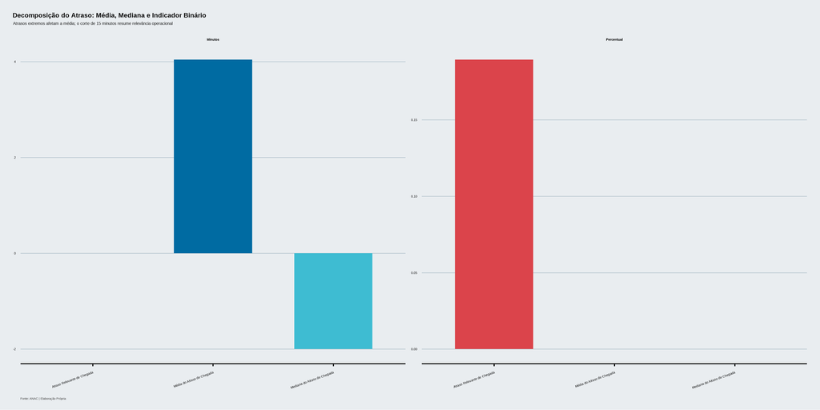

```r
voos_real |>
  summarise(`Média do Atraso de Chegada` = mean(atraso_chegada_min, na.rm = TRUE),
            `Mediana do Atraso de Chegada` = median(atraso_chegada_min, na.rm = TRUE),
            `Atraso Relevante de Chegada` = mean(atraso_relevante_chegada, na.rm = TRUE)) |>
  pivot_longer(everything(), names_to = "Metrica", values_to = "Valor") |>
  mutate(Unidade = if_else(str_detect(Metrica, "Relevante"), "Percentual", "Minutos")) |>
  ggplot(aes(Metrica, Valor, fill = Metrica)) +
    geom_col(show.legend = FALSE, width = 0.65) +
    facet_wrap(~ Unidade, scales = "free_y") +
    scale_econ(aes = "fill", scheme = "web") +
    scale_y_continuous(labels = fmt_lab("number")) +
    labs(title = "Decomposição do Atraso: Média, Mediana e Indicador Binário",
         subtitle = "Atrasos extremos afetam a média; o corte de 15 minutos resume relevância operacional",
         caption = "Fonte: ANAC | Elaboração Própria") +
    theme_econ_base() +
    theme(axis.text.x = element_text(angle = 20, hjust = 1))
```

## 6.4 Quadro Metodológico dos Desfechos

```r
tribble(
  ~ Desfecho,                     ~ Definicao,                              ~ Unidade_Analise,                       ~ Base_Usada,        ~ Limitacao,
  "Atraso relevante de chegada",  "atraso_chegada_min > 15",                "Voos realizados com atraso observado",  "voos_real",         "Não inclui voos cancelados e depende de horários reais preenchidos",
  "Cancelamento",                 "situacao classificada como cancelada",   "Todos os registros de voos",            "voos",              "Não informa a causa do cancelamento quando justificativa está ausente"
) |>
  gt() |>
    tab_header(title = md("**Quadro Metodológico dos Desfechos**"),
               subtitle = "Métricas que organizam a narrativa do relatório") |>
    cols_label(Definicao = "Definição",
               Unidade_Analise = "Unidade de Análise",
               Base_Usada = "Base Usada",
               Limitacao = "Limitação") |>
    cols_align(align = "left",
               columns = c(Desfecho, Definicao, Unidade_Analise, Base_Usada, Limitacao)) |>
    tab_source_note(source_note = "Fonte: ANAC | Elaboração Própria") |>
    tab_options(heading.align = "left",
                column_labels.font.weight = "bold",
                column_labels.border.top.width = px(3),
                column_labels.border.top.color = "#E3120B",
                table.border.bottom.color = "black",
                table_body.hlines.color = "#ececec",
                table.border.top.style = "hidden")
```

**Quadro Metodológico dos Desfechos**

Métricas que organizam a narrativa do relatório

| Desfecho | Definição | Unidade de Análise | Base Usada | Limitação |
| --- | --- | --- | --- | --- |
| Atraso relevante de chegada | atraso_chegada_min > 15 | Voos realizados com atraso observado | voos_real | Não inclui voos cancelados e depende de horários reais preenchidos |
| Cancelamento | situacao classificada como cancelada | Todos os registros de voos | voos | Não informa a causa do cancelamento quando justificativa está ausente |

Fonte: ANAC | Elaboração Própria

# 7 Tópico : Diagnóstico Geral da Operação em 2023

## 7.1 Painel Geral da Operação

```r
voos |>
  filter(year(partida_prevista) == 2023 | is.na(partida_prevista)) |>
  summarise(`Total de Voos` = n(),
            `Voos Realizados` = sum(voo_realizado, na.rm = TRUE),
            `Voos Cancelados` = sum(cancelado, na.rm = TRUE),
            Companhias = n_distinct(empresa, na.rm = TRUE),
            `Aeroportos de Origem` = n_distinct(origem_icao, na.rm = TRUE),
            Rotas = n_distinct(rota, na.rm = TRUE),
            `Assentos Ofertados` = sum(assentos, na.rm = TRUE),
            `Modelos de Equipamento` = n_distinct(modelo_equipamento, na.rm = TRUE)) |>
  pivot_longer(everything(), names_to = "Indicador", values_to = "Valor") |>
  gt() |>
    tab_header(title = md("**Painel Geral da Operação em 2023**"),
               subtitle = "Escala e complexidade da base analisada") |>
    fmt_number(columns = Valor, decimals = 0, sep_mark = ".", dec_mark = ",") |>
    cols_align(align = "left", columns = Indicador) |>
    cols_align(align = "right", columns = Valor) |>
    tab_source_note(source_note = "Fonte: ANAC | Elaboração Própria") |>
    tab_options(heading.align = "left",
                column_labels.font.weight = "bold",
                column_labels.border.top.width = px(3),
                column_labels.border.top.color = "#E3120B",
                table.border.bottom.color = "black",
                table_body.hlines.color = "#ececec",
                table.border.top.style = "hidden")
```

**Painel Geral da Operação em 2023**

Escala e complexidade da base analisada

| Indicador | Valor |
| --- | --- |
| Total de Voos | 958.546 |
| Voos Realizados | 906.627 |
| Voos Cancelados | 51.357 |
| Companhias | 118 |
| Aeroportos de Origem | 389 |
| Rotas | 3.148 |
| Assentos Ofertados | 148.045.923 |
| Modelos de Equipamento | 62 |

Fonte: ANAC | Elaboração Própria

## 7.2 Principais Companhias por Volume de Voos

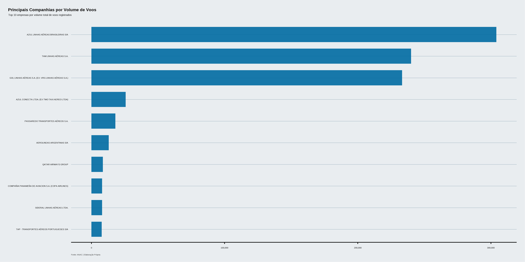

```r
rk_emp <- voos |>
  drop_na(empresa) |>
  summarise(voos = n(),
            assentos = sum(assentos, na.rm = TRUE),
            .by = empresa) |>
  mutate(part_voos = voos / sum(voos),
         part_assentos = assentos / sum(assentos)) |>
  arrange(desc(voos)) |>
  slice_head(n = 10)

rk_emp |>
  mutate(empresa = fct_reorder(empresa, voos)) |>
  ggplot(aes(voos, empresa)) +
    geom_col(fill = pal["blue1"], width = 0.7, alpha = 0.9) +
    scale_x_continuous(labels = fmt_lab("number")) +
    labs(title = "Principais Companhias por Volume de Voos",
         subtitle = "Top 10 empresas por volume total de voos registrados",
         caption = "Fonte: ANAC | Elaboração Própria") +
    theme_econ_base()
```

```r
rk_emp |>
  gt() |>
    tab_header(title = md("**Principais Companhias por Volume**"),
               subtitle = "Voos, assentos ofertados e participação no total") |>
    cols_label(empresa = "Companhia",
               voos = "Voos",
               assentos = "Assentos Ofertados",
               part_voos = "Part. Voos",
               part_assentos = "Part. Assentos") |>
    fmt_number(columns = c(voos, assentos), decimals = 0, sep_mark = ".", dec_mark = ",") |>
    fmt_percent(columns = c(part_voos, part_assentos), decimals = 1, dec_mark = ",", sep_mark = ".") |>
    cols_align(align = "left", columns = empresa) |>
    cols_align(align = "center", columns = c(voos, assentos, part_voos, part_assentos)) |>
    tab_source_note(source_note = "Fonte: ANAC | Elaboração Própria") |>
    tab_options(heading.align = "left",
                column_labels.font.weight = "bold",
                column_labels.border.top.width = px(3),
                column_labels.border.top.color = "#E3120B",
                table.border.bottom.color = "black",
                table_body.hlines.color = "#ececec",
                table.border.top.style = "hidden")
```

**Principais Companhias por Volume**

Voos, assentos ofertados e participação no total

| Companhia | Voos | Assentos Ofertados | Part. Voos | Part. Assentos |
| --- | --- | --- | --- | --- |
| AZUL LINHAS AÉREAS BRASILEIRAS S/A | 304.131 | 39.147.133 | 31,7% | 26,4% |
| TAM LINHAS AÉREAS S.A. | 240.095 | 45.077.713 | 25,0% | 30,4% |
| GOL LINHAS AÉREAS S.A. (EX- VRG LINHAS AÉREAS S.A.) | 233.354 | 40.893.782 | 24,3% | 27,6% |
| AZUL CONECTA LTDA. (EX TWO TAXI AEREO LTDA) | 25.734 | 200.989 | 2,7% | 0,1% |
| PASSAREDO TRANSPORTES AÉREOS S.A. | 17.992 | 1.207.943 | 1,9% | 0,8% |
| AEROLINEAS ARGENTINAS S/A | 13.011 | 2.335.544 | 1,4% | 1,6% |
| QATAR AIRWAYS GROUP | 8.643 | 586.876 | 0,9% | 0,4% |
| COMPAÑIA PANAMEÑA DE AVIACION S.A. (COPA AIRLINES) | 8.067 | 1.314.788 | 0,8% | 0,9% |
| SIDERAL LINHAS AÉREAS LTDA. | 8.031 | 53.190 | 0,8% | 0,0% |
| TAP - TRANSPORTES AÉREOS PORTUGUESES S/A | 7.704 | 2.127.038 | 0,8% | 1,4% |

Fonte: ANAC | Elaboração Própria

## 7.3 Principais Aeroportos de Origem por Partidas

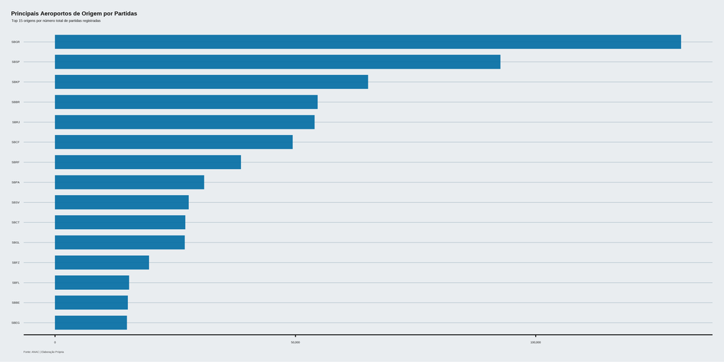

```r
rk_orig <- voos |>
  drop_na(origem_icao) |>
  summarise(partidas = n(),
            assentos = sum(assentos, na.rm = TRUE),
            nome_origem = first(nome_origem[!is.na(nome_origem)], default = NA_character_),
            .by = origem_icao) |>
  mutate(part_partidas = partidas / sum(partidas)) |>
  arrange(desc(partidas)) |>
  slice_head(n = 15)

rk_orig |>
  mutate(origem_icao = fct_reorder(origem_icao, partidas)) |>
  ggplot(aes(partidas, origem_icao)) +
    geom_col(fill = pal["blue1"], width = 0.7, alpha = 0.9) +
    scale_x_continuous(labels = fmt_lab("number")) +
    labs(title = "Principais Aeroportos de Origem por Partidas",
         subtitle = "Top 15 origens por número total de partidas registradas",
         caption = "Fonte: ANAC | Elaboração Própria") +
  theme_econ_base()
```

```r
rk_orig |>
  select(origem_icao, nome_origem, partidas, assentos, part_partidas) |>
  gt() |>
    tab_header(title = md("**Principais Aeroportos de Origem**"),
               subtitle = "Volume e capacidade ofertada como contexto para as análises de desempenho") |>
    cols_label(origem_icao = "Origem",
               nome_origem = "Aeroporto",
               partidas = "Partidas",
               assentos = "Assentos Ofertados",
               part_partidas = "Part. Partidas") |>
    fmt_number(columns = c(partidas, assentos), decimals = 0, sep_mark = ".", dec_mark = ",") |>
    fmt_percent(columns = part_partidas, decimals = 1, dec_mark = ",", sep_mark = ".") |>
    cols_align(align = "left", columns = nome_origem) |>
    cols_align(align = "center", columns = c(origem_icao, partidas, assentos, part_partidas)) |>
    tab_source_note(source_note = "Fonte: ANAC | Elaboração Própria") |>
    tab_options(heading.align = "left",
                column_labels.font.weight = "bold",
                column_labels.border.top.width = px(3),
                column_labels.border.top.color = "#E3120B",
                table.border.bottom.color = "black",
                table_body.hlines.color = "#ececec",
                table.border.top.style = "hidden")
```

**Principais Aeroportos de Origem**

Volume e capacidade ofertada como contexto para as análises de desempenho

| Origem | Aeroporto | Partidas | Assentos Ofertados | Part. Partidas |
| --- | --- | --- | --- | --- |
| SBGR | GUARULHOS - GOVERNADOR ANDRÉ FRANCO MONTORO - GUARULHOS - SP - BRASIL | 130.260 | 24.846.417 | 13,6% |
| SBSP | CONGONHAS - SÃO PAULO - SP - BRASIL | 92.667 | 14.823.939 | 9,7% |
| SBKP | VIRACOPOS - CAMPINAS - SP - BRASIL | 65.120 | 7.850.736 | 6,8% |
| SBBR | PRESIDENTE JUSCELINO KUBITSCHEK - BRASÍLIA - DF - BRASIL | 54.631 | 9.314.366 | 5,7% |
| SBRJ | SANTOS DUMONT - RIO DE JANEIRO - RJ - BRASIL | 54.011 | 8.164.298 | 5,6% |
| SBCF | TANCREDO NEVES - CONFINS - MG - BRASIL | 49.434 | 6.826.814 | 5,2% |
| SBRF | GUARARAPES - GILBERTO FREYRE - RECIFE - PE - BRASIL | 38.687 | 5.515.523 | 4,0% |
| SBPA | SALGADO FILHO - PORTO ALEGRE - RS - BRASIL | 31.041 | 4.860.399 | 3,2% |
| SBSV | DEPUTADO LUÍS EDUARDO MAGALHÃES - SALVADOR - BA - BRASIL | 27.833 | 4.471.906 | 2,9% |
| SBCT | AFONSO PENA - SÃO JOSÉ DOS PINHAIS - PR - BRASIL | 27.127 | 3.733.976 | 2,8% |
| SBGL | AEROPORTO INTERNACIONAL DO RIO DE JANEIRO (GALEÃO) - ANTONIO CARLOS JOBIM - RIO DE JANEIRO - RJ - BRASIL | 26.979 | 5.020.682 | 2,8% |
| SBFZ | PINTO MARTINS - FORTALEZA - CE - BRASIL | 19.567 | 3.268.935 | 2,0% |
| SBFL | HERCÍLIO LUZ - FLORIANÓPOLIS - SC - BRASIL | 15.427 | 2.503.767 | 1,6% |
| SBBE | INTERNACIONAL DE BELÉM/VAL DE CANS/JÚLIO CEZAR RIBEIRO - BELÉM - PA - BRASIL | 15.160 | 2.310.315 | 1,6% |
| SBEG | EDUARDO GOMES - MANAUS - AM - BRASIL | 14.983 | 1.611.049 | 1,6% |

Fonte: ANAC | Elaboração Própria

## 7.4 Top 20 Rotas Mais Voadas

```r
voos |>
  drop_na(origem_icao, destino_icao) |>
  summarise(voos = n(),
            assentos = sum(assentos, na.rm = TRUE),
            atraso_medio_chegada = mean(atraso_chegada_min[voo_realizado], na.rm = TRUE),
            pct_atraso_relevante = mean(atraso_relevante_chegada, na.rm = TRUE),
            taxa_cancelamento = mean(cancelado, na.rm = TRUE),
            .by = c(rota, origem_icao, destino_icao, nome_origem, nome_destino)) |>
  arrange(desc(voos)) |>
  slice_head(n = 20) |>
  select(rota, nome_origem, nome_destino, voos, assentos, atraso_medio_chegada,
         pct_atraso_relevante, taxa_cancelamento) |>
  gt() |>
    tab_header(title = md("**Top 20 Rotas Mais Voadas**"),
               subtitle = "Volume acompanhado de atraso relevante e cancelamento") |>
    cols_label(rota = "Rota",
               nome_origem = "Origem",
               nome_destino = "Destino",
               voos = "Voos",
               assentos = "Assentos",
               atraso_medio_chegada = "Atraso Médio",
               pct_atraso_relevante = "Atraso Relevante",
               taxa_cancelamento = "Cancelamento") |>
    fmt_number(columns = c(voos, assentos), decimals = 0, sep_mark = ".", dec_mark = ",") |>
    fmt_number(columns = atraso_medio_chegada, decimals = 1, dec_mark = ",", sep_mark = ".") |>
    fmt_percent(columns = c(pct_atraso_relevante, taxa_cancelamento),
                decimals = 1, dec_mark = ",", sep_mark = ".") |>
    cols_align(align = "left", columns = c(nome_origem, nome_destino)) |>
    cols_align(align = "center",
               columns = c(rota, voos, assentos, atraso_medio_chegada,
                           pct_atraso_relevante, taxa_cancelamento)) |>
    tab_source_note(source_note = "Fonte: ANAC | Elaboração Própria") |>
    tab_options(heading.align = "left",
                column_labels.font.weight = "bold",
                column_labels.border.top.width = px(3),
                column_labels.border.top.color = "#E3120B",
                table.border.bottom.color = "black",
                table_body.hlines.color = "#ececec",
                table.border.top.style = "hidden")
```

**Top 20 Rotas Mais Voadas**

Volume acompanhado de atraso relevante e cancelamento

| Rota | Origem | Destino | Voos | Assentos | Atraso Médio | Atraso Relevante | Cancelamento |
| --- | --- | --- | --- | --- | --- | --- | --- |
| SBSP -> SBRJ | CONGONHAS - SÃO PAULO - SP - BRASIL | SANTOS DUMONT - RIO DE JANEIRO - RJ - BRASIL | 18.362 | 2.818.737 | 4,0 | 20,0% | 6,2% |
| SBRJ -> SBSP | SANTOS DUMONT - RIO DE JANEIRO - RJ - BRASIL | CONGONHAS - SÃO PAULO - SP - BRASIL | 18.318 | 2.798.483 | 5,6 | 21,9% | 6,4% |
| SBSP -> SBBR | CONGONHAS - SÃO PAULO - SP - BRASIL | PRESIDENTE JUSCELINO KUBITSCHEK - BRASÍLIA - DF - BRASIL | 8.802 | 1.533.704 | 5,9 | 22,2% | 1,7% |
| SBBR -> SBSP | PRESIDENTE JUSCELINO KUBITSCHEK - BRASÍLIA - DF - BRASIL | CONGONHAS - SÃO PAULO - SP - BRASIL | 8.796 | 1.536.224 | 0,6 | 14,4% | 2,4% |
| SBPA -> SBSP | SALGADO FILHO - PORTO ALEGRE - RS - BRASIL | CONGONHAS - SÃO PAULO - SP - BRASIL | 8.407 | 1.480.211 | 4,1 | 19,9% | 3,7% |
| SBSP -> SBPA | CONGONHAS - SÃO PAULO - SP - BRASIL | SALGADO FILHO - PORTO ALEGRE - RS - BRASIL | 8.382 | 1.472.772 | 6,3 | 22,6% | 3,1% |
| SBCF -> SBSP | TANCREDO NEVES - CONFINS - MG - BRASIL | CONGONHAS - SÃO PAULO - SP - BRASIL | 8.182 | 1.308.110 | 7,0 | 21,2% | 3,0% |
| SBSP -> SBCF | CONGONHAS - SÃO PAULO - SP - BRASIL | TANCREDO NEVES - CONFINS - MG - BRASIL | 8.063 | 1.297.583 | 5,7 | 21,9% | 2,1% |
| SBCT -> SBSP | AFONSO PENA - SÃO JOSÉ DOS PINHAIS - PR - BRASIL | CONGONHAS - SÃO PAULO - SP - BRASIL | 6.536 | 1.052.186 | 3,3 | 16,6% | 3,6% |
| SBSP -> SBCT | CONGONHAS - SÃO PAULO - SP - BRASIL | AFONSO PENA - SÃO JOSÉ DOS PINHAIS - PR - BRASIL | 6.531 | 1.052.760 | 6,0 | 21,5% | 2,9% |
| SBPA -> SBGR | SALGADO FILHO - PORTO ALEGRE - RS - BRASIL | GUARULHOS - GOVERNADOR ANDRÉ FRANCO MONTORO - GUARULHOS - SP - BRASIL | 6.375 | 1.066.321 | 6,1 | 21,7% | 3,4% |
| SBGR -> SBPA | GUARULHOS - GOVERNADOR ANDRÉ FRANCO MONTORO - GUARULHOS - SP - BRASIL | SALGADO FILHO - PORTO ALEGRE - RS - BRASIL | 6.308 | 1.063.904 | 5,8 | 20,8% | 2,6% |
| SBGR -> SBRF | GUARULHOS - GOVERNADOR ANDRÉ FRANCO MONTORO - GUARULHOS - SP - BRASIL | GUARARAPES - GILBERTO FREYRE - RECIFE - PE - BRASIL | 5.839 | 1.018.342 | 8,7 | 24,6% | 1,6% |
| SBCF -> SBGR | TANCREDO NEVES - CONFINS - MG - BRASIL | GUARULHOS - GOVERNADOR ANDRÉ FRANCO MONTORO - GUARULHOS - SP - BRASIL | 5.685 | 874.350 | 3,7 | 18,2% | 3,6% |
| SBRF -> SBGR | GUARARAPES - GILBERTO FREYRE - RECIFE - PE - BRASIL | GUARULHOS - GOVERNADOR ANDRÉ FRANCO MONTORO - GUARULHOS - SP - BRASIL | 5.671 | 1.015.188 | 3,0 | 16,8% | 1,6% |
| SBGR -> SBCF | GUARULHOS - GOVERNADOR ANDRÉ FRANCO MONTORO - GUARULHOS - SP - BRASIL | TANCREDO NEVES - CONFINS - MG - BRASIL | 5.399 | 865.449 | 9,0 | 26,1% | 2,7% |
| SBBR -> SBRJ | PRESIDENTE JUSCELINO KUBITSCHEK - BRASÍLIA - DF - BRASIL | SANTOS DUMONT - RIO DE JANEIRO - RJ - BRASIL | 5.224 | 835.357 | 0,1 | 13,1% | 3,0% |
| SBRJ -> SBBR | SANTOS DUMONT - RIO DE JANEIRO - RJ - BRASIL | PRESIDENTE JUSCELINO KUBITSCHEK - BRASÍLIA - DF - BRASIL | 5.182 | 834.688 | 2,6 | 17,0% | 1,8% |
| SBCT -> SBGR | AFONSO PENA - SÃO JOSÉ DOS PINHAIS - PR - BRASIL | GUARULHOS - GOVERNADOR ANDRÉ FRANCO MONTORO - GUARULHOS - SP - BRASIL | 4.875 | 783.369 | 2,1 | 18,7% | 2,6% |
| SBGR -> SBCT | GUARULHOS - GOVERNADOR ANDRÉ FRANCO MONTORO - GUARULHOS - SP - BRASIL | AFONSO PENA - SÃO JOSÉ DOS PINHAIS - PR - BRASIL | 4.832 | 781.849 | −1,1 | 21,4% | 3,1% |

Fonte: ANAC | Elaboração Própria

## 7.5 Sazonalidade Mensal da Operação Aérea em 2023

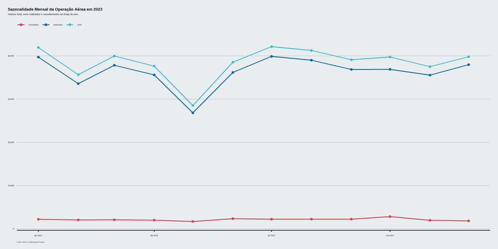

```r
voos |>
  filter(year(partida_prevista) == 2023) |>
  summarise(voos = n(),
            realizados = sum(voo_realizado, na.rm = TRUE),
            cancelados = sum(cancelado, na.rm = TRUE),
            .by = mes) |>
  arrange(mes) |>
  pivot_longer(-mes, names_to = "indicador", values_to = "valor") |>
  ggplot(aes(mes, valor, colour = indicador)) +
    geom_line(linewidth = 0.9) +
    geom_point(size = 1.8) +
    scale_y_continuous(labels = fmt_lab("number")) +
    scale_econ(aes = "colour", scheme = "web") +
    labs(title = "Sazonalidade Mensal da Operação Aérea em 2023",
         subtitle = "Volume total, voos realizados e cancelamentos ao longo do ano",
         caption = "Fonte: ANAC | Elaboração Própria") +
    theme_econ_base()
```

# 8 Tópico : Fatores Associados a Atrasos

## 8.1 Distribuição dos Atrasos de Chegada

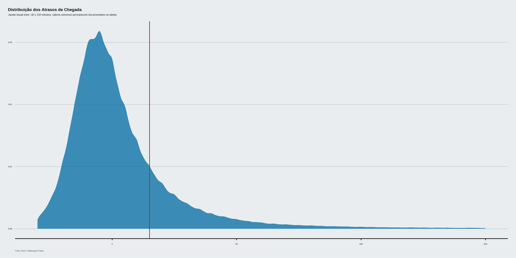

```r
voos_real |>
  filter(between(atraso_chegada_min, -30, 150)) |>
  ggplot(aes(atraso_chegada_min)) +
    geom_density(fill = pal["blue1"], colour = NA, alpha = 0.75) +
    geom_vline(xintercept = 15, colour = pal["econ_red"], linewidth = 0.7) +
    scale_x_continuous(labels = fmt_lab("number")) +
    labs(title = "Distribuição dos Atrasos de Chegada",
         subtitle = "Janela visual entre -30 e 150 minutos; valores extremos permanecem documentados na tabela",
         caption = "Fonte: ANAC | Elaboração Própria") +
    theme_econ_base()
```

```r
voos_real |>
  summarise(voos = n(),
            minimo = min(atraso_chegada_min, na.rm = TRUE),
            p01 = as.numeric(quantile(atraso_chegada_min, 0.01, na.rm = TRUE)),
            mediana = median(atraso_chegada_min, na.rm = TRUE),
            media = mean(atraso_chegada_min, na.rm = TRUE),
            p95 = as.numeric(quantile(atraso_chegada_min, 0.95, na.rm = TRUE)),
            p99 = as.numeric(quantile(atraso_chegada_min, 0.99, na.rm = TRUE)),
            maximo = max(atraso_chegada_min, na.rm = TRUE),
            pct_atraso_relevante = mean(atraso_relevante_chegada, na.rm = TRUE)) |>
  gt() |>
    tab_header(title = md("**Estatísticas dos Atrasos de Chegada**"),
               subtitle = "Resumo completo dos voos realizados com atraso observado") |>
    cols_label(voos = "Voos",
               minimo = "Mínimo",
               p01 = "P01",
               mediana = "Mediana",
               media = "Média",
               p95 = "P95",
               p99 = "P99",
               maximo = "Máximo",
               pct_atraso_relevante = "Atraso Relevante") |>
    fmt_number(columns = c(voos, minimo, p01, mediana, media, p95, p99, maximo),
               decimals = 1, dec_mark = ",", sep_mark = ".") |>
    fmt_percent(columns = pct_atraso_relevante, decimals = 1, dec_mark = ",", sep_mark = ".") |>
    cols_align(align = "center",
               columns = c(voos, minimo, p01, mediana, media, p95, p99, maximo, pct_atraso_relevante)) |>
    tab_source_note(source_note = "Fonte: ANAC | Elaboração Própria") |>
    tab_options(heading.align = "left",
                column_labels.font.weight = "bold",
                column_labels.border.top.width = px(3),
                column_labels.border.top.color = "#E3120B",
                table.border.bottom.color = "black",
                table_body.hlines.color = "#ececec",
                table.border.top.style = "hidden")
```

**Estatísticas dos Atrasos de Chegada**

Resumo completo dos voos realizados com atraso observado

| Voos | Mínimo | P01 | Mediana | Média | P95 | P99 | Máximo | Atraso Relevante |
| --- | --- | --- | --- | --- | --- | --- | --- | --- |
| 871.892,0 | −524.907,0 | −39,0 | −2,0 | 4,0 | 51,0 | 155,0 | 5.652,0 | 18,9% |

Fonte: ANAC | Elaboração Própria

## 8.2 Atraso Relevante por Companhia

```r
voos_real |>
  drop_na(empresa) |>
  summarise(voos_realizados = n(),
            atraso_medio = mean(atraso_chegada_min, na.rm = TRUE),
            atraso_mediano = median(atraso_chegada_min, na.rm = TRUE),
            pct_atraso_relevante = mean(atraso_relevante_chegada, na.rm = TRUE),
            .by = empresa) |>
  filter(voos_realizados >= 1000) |>
  arrange(desc(pct_atraso_relevante)) |>
  slice_head(n = 15) |>
  gt() |>
    tab_header(title = md("**Atraso Relevante por Companhia**"),
               subtitle = "Empresas com pelo menos 1.000 voos realizados") |>
    cols_label(empresa = "Companhia",
               voos_realizados = "Voos Realizados",
               atraso_medio = "Média",
               atraso_mediano = "Mediana",
               pct_atraso_relevante = "Atraso Relevante") |>
    fmt_number(columns = voos_realizados, decimals = 0, sep_mark = ".", dec_mark = ",") |>
    fmt_number(columns = c(atraso_medio, atraso_mediano),
               decimals = 1, dec_mark = ",", sep_mark = ".") |>
    fmt_percent(columns = pct_atraso_relevante, decimals = 1, dec_mark = ",", sep_mark = ".") |>
    cols_align(align = "left", columns = empresa) |>
    cols_align(align = "center",
               columns = c(voos_realizados, atraso_medio, atraso_mediano, pct_atraso_relevante)) |>
    gt_color_rows(columns = pct_atraso_relevante, palette = c("#ffffff", "#E64E53")) |>
    tab_source_note(source_note = "Fonte: ANAC | Elaboração Própria") |>
    tab_options(heading.align = "left",
                column_labels.font.weight = "bold",
                column_labels.border.top.width = px(3),
                column_labels.border.top.color = "#E3120B",
                table.border.bottom.color = "black",
                table_body.hlines.color = "#ececec",
                table.border.top.style = "hidden")
```

**Atraso Relevante por Companhia**

Empresas com pelo menos 1.000 voos realizados

| Companhia | Voos Realizados | Média | Mediana | Atraso Relevante |
| --- | --- | --- | --- | --- |
| LAN CARGO S.A. | 1.916 | 119,0 | 64,0 | 72,7% |
| ATLAS AIR INC | 1.095 | 292,4 | 88,0 | 71,0% |
| TURKISH AIRLINES INC | 1.597 | 28,7 | 14,0 | 47,3% |
| MAP TRANSPORTES AÉREOS LTDA. | 2.978 | 28,9 | 12,0 | 45,5% |
| ABSA - AEROLINHAS BRASILEIRAS S.A. | 1.927 | 30,5 | 10,0 | 43,5% |
| SKY AIRLINE S.A. | 1.720 | 13,0 | 10,0 | 42,5% |
| EMIRATES | 1.593 | 13,3 | 9,0 | 41,7% |
| AIR CANADA | 1.637 | 10,8 | 3,0 | 35,3% |
| SIDERAL LINHAS AÉREAS LTDA. | 6.896 | 14,5 | 10,0 | 34,0% |
| BOA BOLIVIANA DE AVIACIÓN | 1.236 | 13,0 | 6,0 | 33,5% |
| DEUTSCHE LUFTHANSA A.G. | 1.074 | 27,5 | 7,0 | 32,9% |
| ETHIOPIAN AIRLINES GROUP | 1.464 | −42,6 | −1,0 | 29,6% |
| UNITED AIRLINES, INC | 3.142 | 22,1 | 0,0 | 28,8% |
| TAP - TRANSPORTES AÉREOS PORTUGUESES S/A | 7.560 | 4,6 | 3,0 | 28,8% |
| AMERICAN AIRLINES, INC. | 3.706 | 38,9 | −8,0 | 28,7% |

Fonte: ANAC | Elaboração Própria

## 8.3 Atraso Relevante por Aeroporto de Origem

```r
voos_real |>
  drop_na(origem_icao) |>
  summarise(voos_realizados = n(),
            nome_origem = first(nome_origem[!is.na(nome_origem)], default = NA_character_),
            atraso_medio = mean(atraso_chegada_min, na.rm = TRUE),
            atraso_mediano = median(atraso_chegada_min, na.rm = TRUE),
            pct_atraso_relevante = mean(atraso_relevante_chegada, na.rm = TRUE),
            .by = origem_icao) |>
  filter(voos_realizados >= 1000) |>
  arrange(desc(pct_atraso_relevante)) |>
  slice_head(n = 15) |>
  gt() |>
    tab_header(title = md("**Atraso Relevante por Aeroporto de Origem**"),
               subtitle = "Aeroportos com mais de 1.000 voos realizados") |>
    cols_label(origem_icao = "Origem",
               nome_origem = "Aeroporto",
               voos_realizados = "Voos Realizados",
               atraso_medio = "Média",
               atraso_mediano = "Mediana",
               pct_atraso_relevante = "Atraso Relevante") |>
    fmt_number(columns = voos_realizados, decimals = 0, sep_mark = ".", dec_mark = ",") |>
    fmt_number(columns = c(atraso_medio, atraso_mediano),
               decimals = 1, dec_mark = ",", sep_mark = ".") |>
    fmt_percent(columns = pct_atraso_relevante, decimals = 1, dec_mark = ",", sep_mark = ".") |>
    cols_align(align = "left", columns = nome_origem) |>
    cols_align(align = "center",
               columns = c(origem_icao, voos_realizados, atraso_medio,
                           atraso_mediano, pct_atraso_relevante)) |>
    gt_color_rows(columns = pct_atraso_relevante, palette = c("#ffffff", "#E64E53")) |>
    tab_source_note(source_note = "Fonte: ANAC | Elaboração Própria") |>
    tab_options(heading.align = "left",
                column_labels.font.weight = "bold",
                column_labels.border.top.width = px(3),
                column_labels.border.top.color = "#E3120B",
                table.border.bottom.color = "black",
                table_body.hlines.color = "#ececec",
                table.border.top.style = "hidden")
```

**Atraso Relevante por Aeroporto de Origem**

Aeroportos com mais de 1.000 voos realizados

| Origem | Voos Realizados | Aeroporto | Média | Mediana | Atraso Relevante |
| --- | --- | --- | --- | --- | --- |
| EDDF | 1.234 | FRANKFURT INTERNATIONAL AIRPORT - FRANKFURT AM MAIN - ALEMANHA | 49,5 | 10,0 | 42,5% |
| EHAM | 1.246 | AMSTERDAM AIRPORT SCHIPHOL - HAARLEMMERMEER, NEAR AMSTERDAM - HOLANDA | 17,2 | 6,0 | 40,4% |
| LPPT | 4.470 | LISBOA - LISBOA - PORTUGAL | 14,7 | 10,0 | 39,8% |
| KMIA | 4.981 | MIAMI INTERNATIONAL AIRPORT - MIAMI, FLORIDA - ESTADOS UNIDOS DA AMÉRICA | 30,0 | 1,0 | 37,0% |
| LFPG | 1.585 | PARIS-CHARLES DE GAULLE AIRPORT (ROISSY AIRPORT) - PARIS - FRANÇA | 11,9 | 6,0 | 32,4% |
| SBJR | 1.771 | JACAREPAGUÁ - RIO DE JANEIRO - RJ - BRASIL | 11,0 | 1,0 | 26,8% |
| SBGR | 120.786 | GUARULHOS - GOVERNADOR ANDRÉ FRANCO MONTORO - GUARULHOS - SP - BRASIL | 7,3 | 1,0 | 24,7% |
| SAEZ | 4.437 | MINISTRO PISTARINI INTERNATIONAL AIRPORT (EZEIZA INTERNATIONAL AIRPORT) - EZEIZA, BUENOS AIRES PROVINCE - ARGENTINA | 5,6 | −3,0 | 23,9% |
| SBEG | 12.073 | EDUARDO GOMES - MANAUS - AM - BRASIL | 17,0 | 0,0 | 23,6% |
| SBSP | 88.320 | CONGONHAS - SÃO PAULO - SP - BRASIL | 7,3 | 1,0 | 23,6% |
| SCEL | 6.170 | COMODORO ARTURO MERINO BENÍTEZ INTERNATIONAL AIRPORT - SANTIAGO - CHILE | 8,0 | −1,0 | 22,2% |
| SBRP | 4.555 | LEITE LOPES - RIBEIRÃO PRETO - SP - BRASIL | 11,6 | −3,0 | 21,4% |
| SABE | 5.747 | JORGE NEWBERY AIRPORT - BUENOS AIRES - ARGENTINA | 4,2 | −1,0 | 21,1% |
| KJFK | 1.111 | JOHN F. KENNEDY INTERNATIONAL AIRPORT - NEW YORK, NEW YORK - ESTADOS UNIDOS DA AMÉRICA | 47,8 | −11,0 | 21,1% |
| SBNF | 7.997 | MINISTRO VICTOR KONDER - NAVEGANTES - SC - BRASIL | 6,5 | −2,0 | 20,9% |

Fonte: ANAC | Elaboração Própria

## 8.4 Atraso Relevante por Turno de Partida

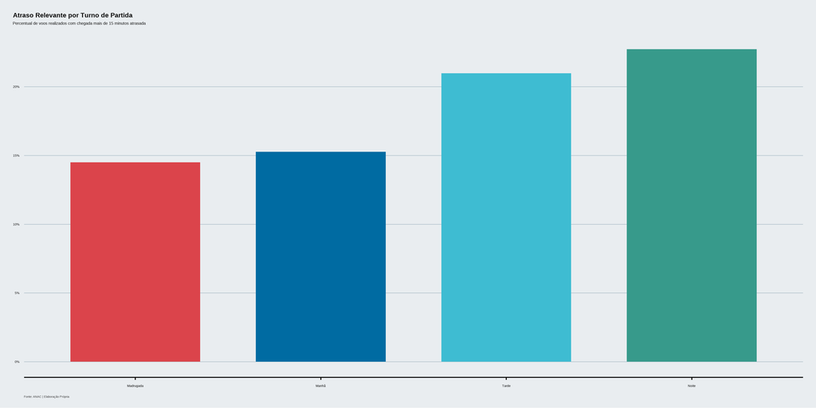

```r
voos_real |>
  drop_na(turno) |>
  summarise(voos_realizados = n(),
            pct_atraso_relevante = mean(atraso_relevante_chegada, na.rm = TRUE),
            atraso_medio = mean(atraso_chegada_min, na.rm = TRUE),
            .by = turno) |>
  ggplot(aes(turno, pct_atraso_relevante, fill = turno)) +
    geom_col(show.legend = FALSE, width = 0.7) +
    scale_y_continuous(labels = fmt_lab("percent")) +
    scale_econ(aes = "fill", scheme = "web") +
    labs(title = "Atraso Relevante por Turno de Partida",
         subtitle = "Percentual de voos realizados com chegada mais de 15 minutos atrasada",
         caption = "Fonte: ANAC | Elaboração Própria") +
    theme_econ_base()
```

## 8.5 Sazonalidade Mensal do Atraso Relevante

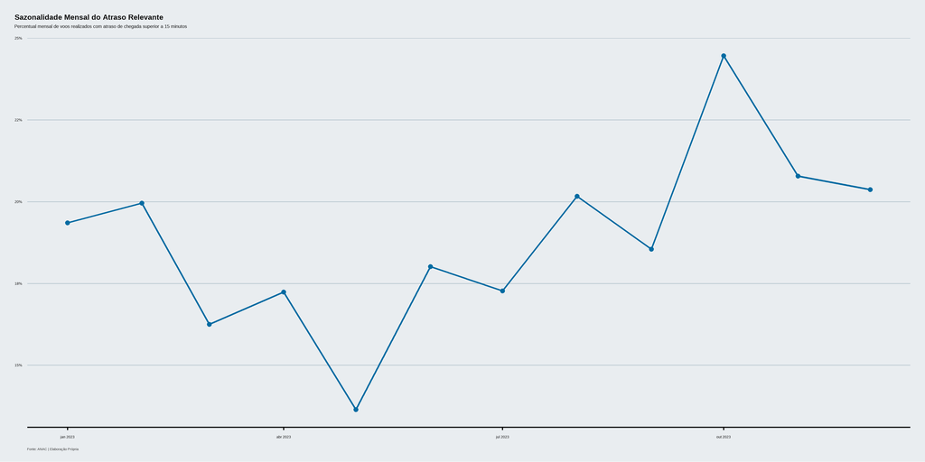

```r
voos_real |>
  filter(year(mes) == 2023) |>
  summarise(voos_realizados = n(),
            pct_atraso_relevante = mean(atraso_relevante_chegada, na.rm = TRUE),
            atraso_medio = mean(atraso_chegada_min, na.rm = TRUE),
            .by = mes) |>
  arrange(mes) |>
  ggplot(aes(mes, pct_atraso_relevante)) +
    geom_line(colour = pal["blue1"], linewidth = 0.9) +
    geom_point(colour = pal["blue1"], size = 1.8) +
    scale_y_continuous(labels = fmt_lab("percent")) +
    labs(title = "Sazonalidade Mensal do Atraso Relevante",
         subtitle = "Percentual mensal de voos realizados com atraso de chegada superior a 15 minutos",
         caption = "Fonte: ANAC | Elaboração Própria") +
    theme_econ_base()
```

## 8.6 Heatmap de Atraso por Mês e Turno

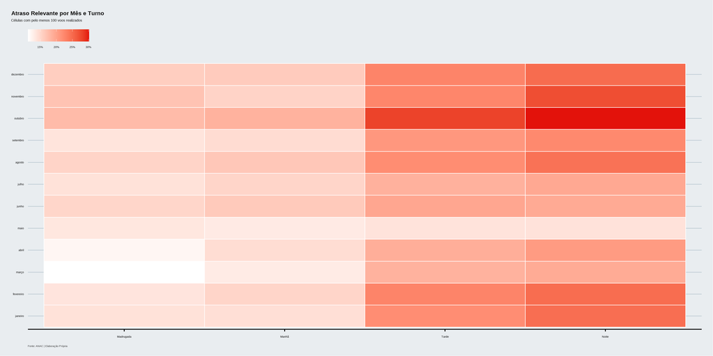

```r
voos_real |>
  filter(year(mes) == 2023) |>
  drop_na(mes_nome, turno) |>
  summarise(voos_realizados = n(),
            pct_atraso_relevante = mean(atraso_relevante_chegada, na.rm = TRUE),
            .by = c(mes_nome, turno)) |>
  filter(voos_realizados >= 100) |>
  ggplot(aes(turno, mes_nome, fill = pct_atraso_relevante)) +
    geom_tile(colour = "white", linewidth = 0.4) +
    scale_fill_gradient(low = "white", high = pal["econ_red"], labels = fmt_lab("percent")) +
    labs(title = "Atraso Relevante por Mês e Turno",
         subtitle = "Células com pelo menos 100 voos realizados",
         fill = "Atraso Relevante",
         caption = "Fonte: ANAC | Elaboração Própria") +
    theme_econ_base() +
    theme(panel.grid = element_blank())
```

# 9 Tópico : Fatores Associados a Cancelamentos

## 9.1 Taxa Geral de Cancelamento

```r
voos |>
  summarise(total_voos = n(),
            voos_cancelados = sum(cancelado, na.rm = TRUE),
            taxa_cancelamento = mean(cancelado, na.rm = TRUE)) |>
  gt() |>
    tab_header(title = md("**Taxa Geral de Cancelamento**"),
               subtitle = "Cancelamento analisado como desfecho próprio, separado dos atrasos") |>
    cols_label(total_voos = "Total de Voos",
               voos_cancelados = "Cancelados",
               taxa_cancelamento = "Taxa") |>
    fmt_number(columns = c(total_voos, voos_cancelados),
               decimals = 0, sep_mark = ".", dec_mark = ",") |>
    fmt_percent(columns = taxa_cancelamento, decimals = 1, dec_mark = ",", sep_mark = ".") |>
    cols_align(align = "center", columns = c(total_voos, voos_cancelados, taxa_cancelamento)) |>
    tab_source_note(source_note = "Fonte: ANAC | Elaboração Própria") |>
    tab_options(heading.align = "left",
                column_labels.font.weight = "bold",
                column_labels.border.top.width = px(3),
                column_labels.border.top.color = "#E3120B",
                table.border.bottom.color = "black",
                table_body.hlines.color = "#ececec",
                table.border.top.style = "hidden")
```

**Taxa Geral de Cancelamento**

Cancelamento analisado como desfecho próprio, separado dos atrasos

| Total de Voos | Cancelados | Taxa |
| --- | --- | --- |
| 958.566 | 51.363 | 5,4% |

Fonte: ANAC | Elaboração Própria

## 9.2 Cancelamento por Companhia

```r
voos |>
  drop_na(empresa) |>
  summarise(total_voos = n(),
            cancelados = sum(cancelado, na.rm = TRUE),
            taxa_cancelamento = mean(cancelado, na.rm = TRUE),
            .by = empresa) |>
  filter(total_voos >= 1000) |>
  arrange(desc(taxa_cancelamento)) |>
  slice_head(n = 15) |>
  gt() |>
    tab_header(title = md("**Cancelamento por Companhia**"),
               subtitle = "Empresas com pelo menos 1.000 voos registrados") |>
    cols_label(empresa = "Companhia",
               total_voos = "Voos",
               cancelados = "Cancelados",
               taxa_cancelamento = "Taxa") |>
    fmt_number(columns = c(total_voos, cancelados),
               decimals = 0, sep_mark = ".", dec_mark = ",") |>
    fmt_percent(columns = taxa_cancelamento, decimals = 1, dec_mark = ",", sep_mark = ".") |>
    cols_align(align = "left", columns = empresa) |>
    cols_align(align = "center", columns = c(total_voos, cancelados, taxa_cancelamento)) |>
    gt_color_rows(columns = taxa_cancelamento, palette = c("#ffffff", "#E64E53")) |>
    tab_source_note(source_note = "Fonte: ANAC | Elaboração Própria") |>
    tab_options(heading.align = "left",
                column_labels.font.weight = "bold",
                column_labels.border.top.width = px(3),
                column_labels.border.top.color = "#E3120B",
                table.border.bottom.color = "black",
                table_body.hlines.color = "#ececec",
                table.border.top.style = "hidden")
```

**Cancelamento por Companhia**

Empresas com pelo menos 1.000 voos registrados

| Companhia | Voos | Cancelados | Taxa |
| --- | --- | --- | --- |
| IBÉRIA LINEAS AEREAS DE ESPAÑA SOCIEDAD ANONIMA OPERADORA | 4.172 | 3.102 | 74,4% |
| QATAR AIRWAYS GROUP | 8.643 | 6.287 | 72,7% |
| ITALIA TRANSPORTO AEREO S.P.A. | 1.813 | 777 | 42,9% |
| AEROLINEAS ARGENTINAS S/A | 13.011 | 5.293 | 40,7% |
| ETHIOPIAN AIRLINES GROUP | 2.777 | 909 | 32,7% |
| ATLAS AIR INC | 2.473 | 796 | 32,2% |
| SKY AIRLINE S.A. | 2.507 | 717 | 28,6% |
| AZUL CONECTA LTDA. (EX TWO TAXI AEREO LTDA) | 25.734 | 5.477 | 21,3% |
| MARTINAIR HOLLAND N.V. | 1.217 | 231 | 19,0% |
| MAP TRANSPORTES AÉREOS LTDA. | 4.326 | 737 | 17,0% |
| TAMPA CARGO S.A. | 1.328 | 214 | 16,1% |
| KOREAN AIR LINES CO. LTD. | 1.211 | 183 | 15,1% |
| ABSA - AEROLINHAS BRASILEIRAS S.A. | 4.265 | 629 | 14,7% |
| CARGOLUX AIRLINES INTERNATIONAL S/A | 1.296 | 177 | 13,7% |
| ATA - AEROTÁXI ABAETÉ LTDA. | 1.032 | 136 | 13,2% |

Fonte: ANAC | Elaboração Própria

## 9.3 Taxa de Cancelamento por Aeroporto de Origem

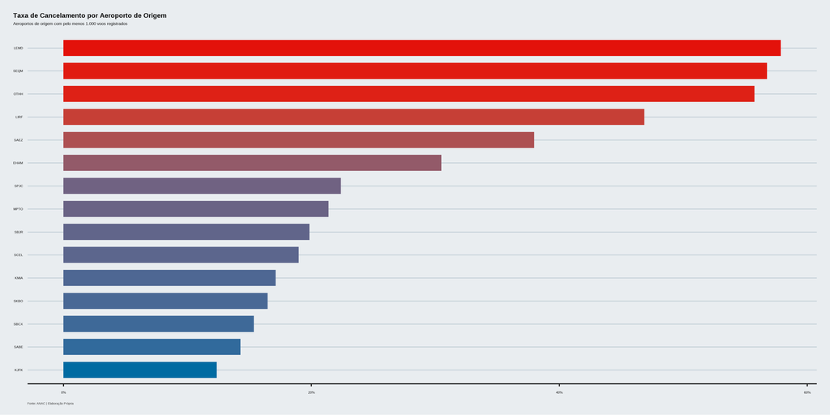

```r
rk_canc <- voos |>
  drop_na(origem_icao) |>
  summarise(total_voos = n(),
            cancelados = sum(cancelado, na.rm = TRUE),
            taxa_cancelamento = mean(cancelado, na.rm = TRUE),
            nome_origem = first(nome_origem[!is.na(nome_origem)], default = NA_character_),
            .by = origem_icao) |>
  filter(total_voos >= 1000) |>
  arrange(desc(taxa_cancelamento)) |>
  slice_head(n = 15)

rk_canc |>
  mutate(origem_icao = fct_reorder(origem_icao, taxa_cancelamento)) |>
  ggplot(aes(taxa_cancelamento, origem_icao, fill = taxa_cancelamento)) +
    geom_col(show.legend = FALSE, width = 0.7) +
    scale_x_continuous(labels = fmt_lab("percent")) +
    scale_fill_gradient(low = pal["blue1"], high = pal["econ_red"]) +
    labs(title = "Taxa de Cancelamento por Aeroporto de Origem",
         subtitle = "Aeroportos de origem com pelo menos 1.000 voos registrados",
         caption = "Fonte: ANAC | Elaboração Própria") +
    theme_econ_base()
```

```r
rk_canc |>
  gt() |>
    tab_header(title = md("**Cancelamento por Aeroporto de Origem**"),
               subtitle = "Taxa acompanhada do volume de voos") |>
    cols_label(origem_icao = "Origem",
               nome_origem = "Aeroporto",
               total_voos = "Voos",
               cancelados = "Cancelados",
               taxa_cancelamento = "Taxa") |>
    fmt_number(columns = c(total_voos, cancelados),
               decimals = 0, sep_mark = ".", dec_mark = ",") |>
    fmt_percent(columns = taxa_cancelamento, decimals = 1, dec_mark = ",", sep_mark = ".") |>
    cols_align(align = "left", columns = nome_origem) |>
    cols_align(align = "center", columns = c(origem_icao, total_voos, cancelados, taxa_cancelamento)) |>
    gt_color_rows(columns = taxa_cancelamento, palette = c("#ffffff", "#E64E53")) |>
    tab_source_note(source_note = "Fonte: ANAC | Elaboração Própria") |>
    tab_options(heading.align = "left",
                column_labels.font.weight = "bold",
                column_labels.border.top.width = px(3),
                column_labels.border.top.color = "#E3120B",
                table.border.bottom.color = "black",
                table_body.hlines.color = "#ececec",
                table.border.top.style = "hidden")
```

**Cancelamento por Aeroporto de Origem**

Taxa acompanhada do volume de voos

| Origem | Voos | Cancelados | Taxa | Aeroporto |
| --- | --- | --- | --- | --- |
| LEMD | 3.314 | 1.918 | 57,9% | ADOLFO SUÁREZ MADRID-BARAJAS AIRPORT - MADRID - ESPANHA |
| SEQM | 2.199 | 1.248 | 56,8% | MARISCAL SUCRE INTERNATIONAL AIRPORT - QUITO - EQUADOR |
| OTHH | 1.652 | 921 | 55,8% | HAMAD INTERNATIONAL AIRPORT - DOHA - QATAR |
| LIRF | 1.257 | 589 | 46,9% | LEONARDO DA VINCI INTERNATIONAL AIRPORT (FIUMICINO INTERNATIONAL AIRPORT) - ROME - ITÁLIA |
| SAEZ | 7.722 | 2.932 | 38,0% | MINISTRO PISTARINI INTERNATIONAL AIRPORT (EZEIZA INTERNATIONAL AIRPORT) - EZEIZA, BUENOS AIRES PROVINCE - ARGENTINA |
| EHAM | 1.932 | 589 | 30,5% | AMSTERDAM AIRPORT SCHIPHOL - HAARLEMMERMEER, NEAR AMSTERDAM - HOLANDA |
| SPJC | 2.766 | 619 | 22,4% | JORGE CHÁVEZ INTERNATIONAL AIRPORT - CALLAO/LIMA, LIMA METROPOLITAN AREA - PERU |
| MPTO | 4.890 | 1.046 | 21,4% | TOCUMEN INTL - PANAMA - PANAMÁ |
| SBJR | 2.243 | 445 | 19,8% | JACAREPAGUÁ - RIO DE JANEIRO - RJ - BRASIL |
| SCEL | 8.084 | 1.534 | 19,0% | COMODORO ARTURO MERINO BENÍTEZ INTERNATIONAL AIRPORT - SANTIAGO - CHILE |
| KMIA | 7.452 | 1.276 | 17,1% | MIAMI INTERNATIONAL AIRPORT - MIAMI, FLORIDA - ESTADOS UNIDOS DA AMÉRICA |
| SKBO | 3.162 | 521 | 16,5% | EL DORADO INTERNATIONAL AIRPORT - BOGOTÁ - COLÔMBIA |
| SBCX | 1.347 | 207 | 15,4% | REGIONAL HUGO CANTERGIANI - CAXIAS DO SUL - RS - BRASIL |
| SABE | 7.287 | 1.041 | 14,3% | JORGE NEWBERY AIRPORT - BUENOS AIRES - ARGENTINA |
| KJFK | 1.318 | 163 | 12,4% | JOHN F. KENNEDY INTERNATIONAL AIRPORT - NEW YORK, NEW YORK - ESTADOS UNIDOS DA AMÉRICA |

Fonte: ANAC | Elaboração Própria

## 9.4 Sazonalidade Mensal da Taxa de Cancelamento

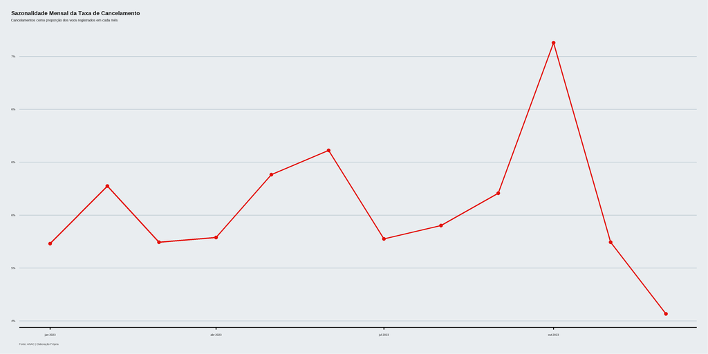

```r
voos |>
  filter(year(partida_prevista) == 2023) |>
  summarise(total_voos = n(),
            cancelados = sum(cancelado, na.rm = TRUE),
            taxa_cancelamento = mean(cancelado, na.rm = TRUE),
            .by = mes) |>
  arrange(mes) |>
  ggplot(aes(mes, taxa_cancelamento)) +
    geom_line(colour = pal["econ_red"], linewidth = 0.9) +
    geom_point(colour = pal["econ_red"], size = 1.8) +
    scale_y_continuous(labels = fmt_lab("percent")) +
    labs(title = "Sazonalidade Mensal da Taxa de Cancelamento",
         subtitle = "Cancelamentos como proporção dos voos registrados em cada mês",
         caption = "Fonte: ANAC | Elaboração Própria") +
    theme_econ_base()
```

## 9.5 Volume Operacional e Taxa de Cancelamento por Aeroporto

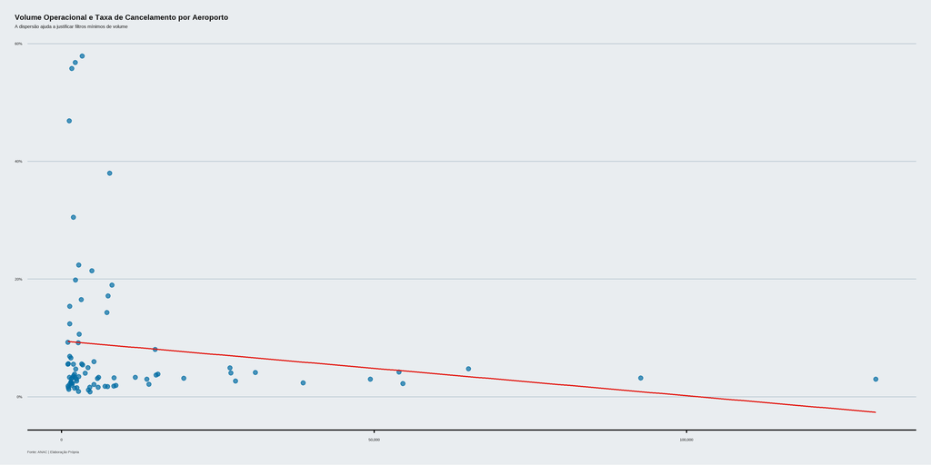

```r
voos |>
  drop_na(origem_icao) |>
  summarise(total_voos = n(),
            cancelados = sum(cancelado, na.rm = TRUE),
            taxa_cancelamento = mean(cancelado, na.rm = TRUE),
            nome_origem = first(nome_origem[!is.na(nome_origem)], default = NA_character_),
            .by = origem_icao) |>
  filter(total_voos >= 1000) |>
  ggplot(aes(total_voos, taxa_cancelamento)) +
    geom_point(colour = pal["blue1"], alpha = 0.7, size = 2) +
    geom_smooth(method = "lm", se = FALSE, colour = pal["econ_red"], linewidth = 0.7) +
    scale_x_continuous(labels = fmt_lab("number")) +
    scale_y_continuous(labels = fmt_lab("percent")) +
    labs(title = "Volume Operacional e Taxa de Cancelamento por Aeroporto",
         subtitle = "A dispersão ajuda a justificar filtros mínimos de volume",
         caption = "Fonte: ANAC | Elaboração Própria") +
    theme_econ_base()
```

# 10 Tópico : Malha, Rotas e Geografia

## 10.1 Conectividade e Desempenho por Aeroporto

```r
ap_perf <- voos |>
  drop_na(origem_icao) |>
  summarise(partidas = n(),
            destinos_distintos = n_distinct(destino_icao, na.rm = TRUE),
            voos_realizados = sum(voo_realizado, na.rm = TRUE),
            pct_atraso_relevante = mean(atraso_relevante_chegada, na.rm = TRUE),
            taxa_cancelamento = mean(cancelado, na.rm = TRUE),
            assentos = sum(assentos, na.rm = TRUE),
            nome_origem = first(nome_origem[!is.na(nome_origem)], default = NA_character_),
            estado_origem = first(estado_origem[!is.na(estado_origem)], default = NA_character_),
            latitude_origem = first(latitude_origem[!is.na(latitude_origem)], default = NA_real_),
            longitude_origem = first(longitude_origem[!is.na(longitude_origem)], default = NA_real_),
            .by = origem_icao) |>
  mutate(part_partidas = partidas / sum(partidas),
         status_hub = if_else(part_partidas >= 0.05 |
                                destinos_distintos >= quantile(destinos_distintos, 0.9, na.rm = TRUE),
                              "Hub", "Demais Aeroportos")) |>
  arrange(desc(destinos_distintos), desc(partidas)) |>
  set_variable_labels(partidas = "Total de partidas registradas no aeroporto",
                      destinos_distintos = "Quantidade de destinos diferentes operados",
                      voos_realizados = "Quantidade de voos efetivamente realizados",
                      pct_atraso_relevante = "Percentual de voos realizados com atraso superior a 15 minutos",
                      taxa_cancelamento = "Proporção de voos cancelados",
                      part_partidas = "Participação do aeroporto no total de partidas",
                      status_hub = "Classificação de hub (>= 5% das partidas ou top 10% em destinos)")

ap_perf |>
  filter(partidas >= 1000) |>
  slice_head(n = 20) |>
  select(origem_icao, nome_origem, destinos_distintos, partidas,
         pct_atraso_relevante, taxa_cancelamento) |>
  gt() |>
    tab_header(title = md("**Conectividade e Desempenho por Aeroporto**"),
               subtitle = "Conectividade usada como contexto para atraso e cancelamento") |>
    cols_label(origem_icao = "Origem",
               nome_origem = "Aeroporto",
               destinos_distintos = "Destinos Distintos",
               partidas = "Partidas",
               pct_atraso_relevante = "Atraso Relevante",
               taxa_cancelamento = "Cancelamento") |>
    fmt_number(columns = c(destinos_distintos, partidas),
               decimals = 0, sep_mark = ".", dec_mark = ",") |>
    fmt_percent(columns = c(pct_atraso_relevante, taxa_cancelamento),
                decimals = 1, dec_mark = ",", sep_mark = ".") |>
    cols_align(align = "left", columns = nome_origem) |>
    cols_align(align = "center",
               columns = c(origem_icao, destinos_distintos, partidas,
                           pct_atraso_relevante, taxa_cancelamento)) |>
    tab_source_note(source_note = "Fonte: ANAC | Elaboração Própria") |>
    tab_options(heading.align = "left",
                column_labels.font.weight = "bold",
                column_labels.border.top.width = px(3),
                column_labels.border.top.color = "#E3120B",
                table.border.bottom.color = "black",
                table_body.hlines.color = "#ececec",
                table.border.top.style = "hidden")
```

**Conectividade e Desempenho por Aeroporto**

Conectividade usada como contexto para atraso e cancelamento

| Origem | Aeroporto | Destinos Distintos | Partidas | Atraso Relevante | Cancelamento |
| --- | --- | --- | --- | --- | --- |
| SBGR | GUARULHOS - GOVERNADOR ANDRÉ FRANCO MONTORO - GUARULHOS - SP - BRASIL | 157 | 130.260 | 24,7% | 3,0% |
| SBKP | VIRACOPOS - CAMPINAS - SP - BRASIL | 128 | 65.120 | 16,9% | 4,7% |
| SBGL | AEROPORTO INTERNACIONAL DO RIO DE JANEIRO (GALEÃO) - ANTONIO CARLOS JOBIM - RIO DE JANEIRO - RJ - BRASIL | 94 | 26.979 | 20,0% | 4,9% |
| SBCF | TANCREDO NEVES - CONFINS - MG - BRASIL | 89 | 49.434 | 16,0% | 3,0% |
| SBEG | EDUARDO GOMES - MANAUS - AM - BRASIL | 79 | 14.983 | 23,6% | 8,0% |
| SBBR | PRESIDENTE JUSCELINO KUBITSCHEK - BRASÍLIA - DF - BRASIL | 76 | 54.631 | 14,3% | 2,2% |
| SBRF | GUARARAPES - GILBERTO FREYRE - RECIFE - PE - BRASIL | 63 | 38.687 | 14,6% | 2,4% |
| SBCT | AFONSO PENA - SÃO JOSÉ DOS PINHAIS - PR - BRASIL | 59 | 27.127 | 16,5% | 4,0% |
| SBPA | SALGADO FILHO - PORTO ALEGRE - RS - BRASIL | 58 | 31.041 | 18,5% | 4,1% |
| SBSV | DEPUTADO LUÍS EDUARDO MAGALHÃES - SALVADOR - BA - BRASIL | 56 | 27.833 | 16,6% | 2,7% |
| SBSP | CONGONHAS - SÃO PAULO - SP - BRASIL | 55 | 92.667 | 23,6% | 3,2% |
| SBFZ | PINTO MARTINS - FORTALEZA - CE - BRASIL | 53 | 19.567 | 16,1% | 3,1% |
| SBBE | INTERNACIONAL DE BELÉM/VAL DE CANS/JÚLIO CEZAR RIBEIRO - BELÉM - PA - BRASIL | 52 | 15.160 | 14,9% | 3,7% |
| SBCY | MARECHAL RONDON - VÁRZEA GRANDE - MT - BRASIL | 51 | 11.821 | 13,6% | 3,3% |
| SBFL | HERCÍLIO LUZ - FLORIANÓPOLIS - SC - BRASIL | 50 | 15.427 | 18,0% | 3,8% |
| KMIA | MIAMI INTERNATIONAL AIRPORT - MIAMI, FLORIDA - ESTADOS UNIDOS DA AMÉRICA | 44 | 7.452 | 37,0% | 17,1% |
| SBPS | PORTO SEGURO - PORTO SEGURO - BA - BRASIL | 39 | 7.399 | 17,3% | 1,7% |
| SAEZ | MINISTRO PISTARINI INTERNATIONAL AIRPORT (EZEIZA INTERNATIONAL AIRPORT) - EZEIZA, BUENOS AIRES PROVINCE - ARGENTINA | 38 | 7.722 | 23,9% | 38,0% |
| SBMO | ZUMBI DOS PALMARES - RIO LARGO - AL - BRASIL | 36 | 8.731 | 12,2% | 1,9% |
| SBSG | GOVERNADOR ALUIZIO ALVES - SÃO GONÇALO DO AMARANTE - RN - BRASIL | 36 | 8.376 | 12,9% | 1,8% |

Fonte: ANAC | Elaboração Própria

## 10.2 Desempenho Operacional: Hubs vs. Demais Aeroportos

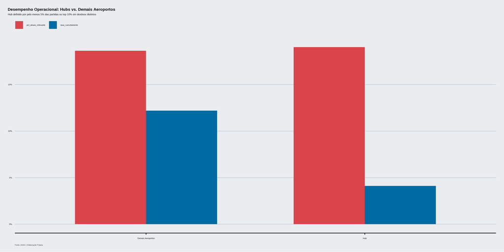

```r
voos |>
  left_join(ap_perf |> select(origem_icao, status_hub), by = "origem_icao") |>
  mutate(status_hub = replace_na(status_hub, "Demais Aeroportos")) |>
  summarise(aeroportos = n_distinct(origem_icao, na.rm = TRUE),
            partidas = n(),
            voos_realizados = sum(voo_realizado, na.rm = TRUE),
            pct_atraso_relevante = mean(atraso_relevante_chegada, na.rm = TRUE),
            taxa_cancelamento = mean(cancelado, na.rm = TRUE),
            .by = status_hub) |>
  pivot_longer(c(pct_atraso_relevante, taxa_cancelamento),
               names_to = "indicador", values_to = "valor") |>
  ggplot(aes(status_hub, valor, fill = indicador)) +
    geom_col(position = "dodge", width = 0.65) +
    scale_y_continuous(labels = fmt_lab("percent")) +
    scale_econ(aes = "fill", scheme = "web") +
    labs(title = "Desempenho Operacional: Hubs vs. Demais Aeroportos",
         subtitle = "Hub definido por pelo menos 5% das partidas ou top 10% em destinos distintos",
         caption = "Fonte: ANAC | Elaboração Própria") +
    theme_econ_base()
```

```r
voos |>
  left_join(ap_perf |> select(origem_icao, status_hub), by = "origem_icao") |>
  mutate(status_hub = replace_na(status_hub, "Demais Aeroportos")) |>
  summarise(aeroportos = n_distinct(origem_icao, na.rm = TRUE),
            partidas = n(),
            voos_realizados = sum(voo_realizado, na.rm = TRUE),
            pct_atraso_relevante = mean(atraso_relevante_chegada, na.rm = TRUE),
            taxa_cancelamento = mean(cancelado, na.rm = TRUE),
            .by = status_hub) |>
  gt() |>
    tab_header(title = md("**Comparação entre Hubs e Demais Aeroportos**"),
               subtitle = "Critério: participação nas partidas ou conectividade elevada") |>
    cols_label(status_hub = "Grupo",
               aeroportos = "Aeroportos",
               partidas = "Partidas",
               voos_realizados = "Voos Realizados",
               pct_atraso_relevante = "Atraso Relevante",
               taxa_cancelamento = "Cancelamento") |>
    fmt_number(columns = c(aeroportos, partidas, voos_realizados),
               decimals = 0, sep_mark = ".", dec_mark = ",") |>
    fmt_percent(columns = c(pct_atraso_relevante, taxa_cancelamento),
                decimals = 1, dec_mark = ",", sep_mark = ".") |>
    cols_align(align = "left", columns = status_hub) |>
    cols_align(align = "center",
               columns = c(aeroportos, partidas, voos_realizados,
                           pct_atraso_relevante, taxa_cancelamento)) |>
    tab_source_note(source_note = "Fonte: ANAC | Elaboração Própria") |>
    tab_options(heading.align = "left",
                column_labels.font.weight = "bold",
                column_labels.border.top.width = px(3),
                column_labels.border.top.color = "#E3120B",
                table.border.bottom.color = "black",
                table_body.hlines.color = "#ececec",
                table.border.top.style = "hidden")
```

**Comparação entre Hubs e Demais Aeroportos**

Critério: participação nas partidas ou conectividade elevada

| Grupo | Aeroportos | Partidas | Voos Realizados | Atraso Relevante | Cancelamento |
| --- | --- | --- | --- | --- | --- |
| Hub | 39 | 811.137 | 777.530 | 19,0% | 4,1% |
| Demais Aeroportos | 350 | 147.429 | 129.110 | 18,6% | 12,2% |

Fonte: ANAC | Elaboração Própria

## 10.3 Distribuição Geográfica dos Aeroportos por Atraso Relevante

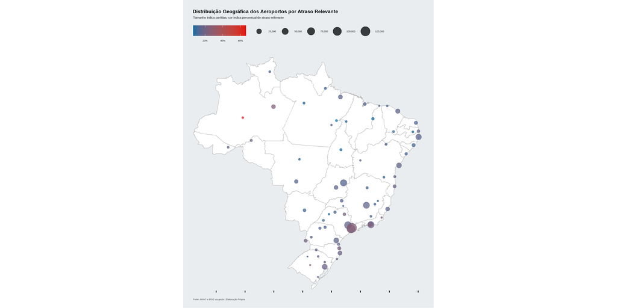

```r
read_state(year = 2020, showProgress = FALSE) |>
  ggplot() +
    geom_sf(fill = "white", colour = "gray70", linewidth = 0.25) +
    geom_sf(data = ap_perf |>
              filter(partidas >= 500,
                     !is.na(latitude_origem),
                     !is.na(longitude_origem),
                     !is.na(estado_origem)) |>
              st_as_sf(coords = c("longitude_origem", "latitude_origem"), crs = 4326),
            aes(size = partidas, colour = pct_atraso_relevante),
            alpha = 0.75) +
    scale_size_continuous(range = c(1, 7), labels = fmt_lab("number")) +
    scale_colour_gradient(low = pal["blue1"], high = pal["econ_red"], labels = fmt_lab("percent")) +
    coord_sf(xlim = c(-74, -34), ylim = c(-34, 6), expand = FALSE) +
    labs(title = "Distribuição Geográfica dos Aeroportos por Atraso Relevante",
         subtitle = "Tamanho indica partidas; cor indica percentual de atraso relevante",
         size = "Partidas",
         colour = "Atraso Relevante",
         caption = "Fonte: ANAC e IBGE via geobr | Elaboração Própria") +
    theme_econ_base() +
    theme(axis.text = element_blank(),
          axis.ticks = element_blank(),
          axis.line.x = element_blank(),
          panel.grid = element_blank())
```

## 10.4 Fluxos Regionais e Taxa de Atraso Relevante

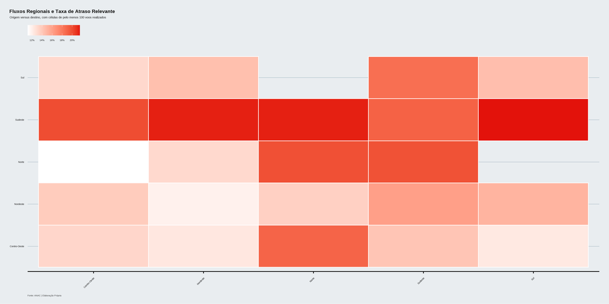

```r
voos_real |>
  drop_na(regiao_origem, regiao_destino) |>
  summarise(voos = n(),
            pct_atraso_relevante = mean(atraso_relevante_chegada, na.rm = TRUE),
            .by = c(regiao_origem, regiao_destino)) |>
  filter(voos >= 100) |>
  ggplot(aes(regiao_destino, regiao_origem, fill = pct_atraso_relevante)) +
    geom_tile(colour = "white", linewidth = 0.5) +
    scale_fill_gradient(low = "white", high = pal["econ_red"], labels = fmt_lab("percent")) +
    labs(title = "Fluxos Regionais e Taxa de Atraso Relevante",
         subtitle = "Origem versus destino, com células de pelo menos 100 voos realizados",
         fill = "Atraso Relevante",
         caption = "Fonte: ANAC | Elaboração Própria") +
    theme_econ_base() +
    theme(panel.grid = element_blank(),
          axis.text.x = element_text(angle = 45, hjust = 1))
```

## 10.5 Rotas Críticas: Alto Volume e Desempenho Pior que a Média

```r
voos |>
  drop_na(origem_icao, destino_icao) |>
  summarise(voos = n(),
            assentos = sum(assentos, na.rm = TRUE),
            pct_atraso_relevante = mean(atraso_relevante_chegada, na.rm = TRUE),
            taxa_cancelamento = mean(cancelado, na.rm = TRUE),
            atraso_medio_chegada = mean(atraso_chegada_min[voo_realizado], na.rm = TRUE),
            .by = c(rota, nome_origem, nome_destino)) |>
  filter(voos >= 1000,
         pct_atraso_relevante > mean(.env$voos$atraso_relevante_chegada, na.rm = TRUE),
         taxa_cancelamento > mean(.env$voos$cancelado, na.rm = TRUE)) |>
  arrange(desc(voos), desc(pct_atraso_relevante), desc(taxa_cancelamento)) |>
  slice_head(n = 20) |>
  gt() |>
    tab_header(title = md("**Rotas Críticas**"),
               subtitle = "Rotas com alto volume e desempenho pior que a média em atraso e cancelamento") |>
    cols_label(rota = "Rota",
               nome_origem = "Origem",
               nome_destino = "Destino",
               voos = "Voos",
               assentos = "Assentos",
               atraso_medio_chegada = "Atraso Médio",
               pct_atraso_relevante = "Atraso Relevante",
               taxa_cancelamento = "Cancelamento") |>
    fmt_number(columns = c(voos, assentos), decimals = 0, sep_mark = ".", dec_mark = ",") |>
    fmt_number(columns = atraso_medio_chegada, decimals = 1, dec_mark = ",", sep_mark = ".") |>
    fmt_percent(columns = c(pct_atraso_relevante, taxa_cancelamento),
                decimals = 1, dec_mark = ",", sep_mark = ".") |>
    cols_align(align = "left", columns = c(nome_origem, nome_destino)) |>
    cols_align(align = "center",
               columns = c(rota, voos, assentos, atraso_medio_chegada,
                           pct_atraso_relevante, taxa_cancelamento)) |>
    gt_color_rows(columns = pct_atraso_relevante, palette = c("#ffffff", "#E64E53")) |>
    tab_source_note(source_note = "Fonte: ANAC | Elaboração Própria") |>
    tab_options(heading.align = "left",
                column_labels.font.weight = "bold",
                column_labels.border.top.width = px(3),
                column_labels.border.top.color = "#E3120B",
                table.border.bottom.color = "black",
                table_body.hlines.color = "#ececec",
                table.border.top.style = "hidden")
```

**Rotas Críticas**

Rotas com alto volume e desempenho pior que a média em atraso e cancelamento

| Rota | Origem | Destino | Voos | Assentos | Atraso Relevante | Cancelamento | Atraso Médio |
| --- | --- | --- | --- | --- | --- | --- | --- |
| SBSP -> SBRJ | CONGONHAS - SÃO PAULO - SP - BRASIL | SANTOS DUMONT - RIO DE JANEIRO - RJ - BRASIL | 18.362 | 2.818.737 | 20,0% | 6,2% | 4,0 |
| SBRJ -> SBSP | SANTOS DUMONT - RIO DE JANEIRO - RJ - BRASIL | CONGONHAS - SÃO PAULO - SP - BRASIL | 18.318 | 2.798.483 | 21,9% | 6,4% | 5,6 |
| SBGR -> SCEL | GUARULHOS - GOVERNADOR ANDRÉ FRANCO MONTORO - GUARULHOS - SP - BRASIL | COMODORO ARTURO MERINO BENÍTEZ INTERNATIONAL AIRPORT - SANTIAGO - CHILE | 4.346 | 699.951 | 34,7% | 13,5% | 17,0 |
| SCEL -> SBGR | COMODORO ARTURO MERINO BENÍTEZ INTERNATIONAL AIRPORT - SANTIAGO - CHILE | GUARULHOS - GOVERNADOR ANDRÉ FRANCO MONTORO - GUARULHOS - SP - BRASIL | 3.633 | 709.271 | 25,0% | 7,8% | 8,7 |
| SABE -> SBGR | JORGE NEWBERY AIRPORT - BUENOS AIRES - ARGENTINA | GUARULHOS - GOVERNADOR ANDRÉ FRANCO MONTORO - GUARULHOS - SP - BRASIL | 3.453 | 603.872 | 24,0% | 6,7% | 7,5 |
| SBEG -> SBKP | EDUARDO GOMES - MANAUS - AM - BRASIL | VIRACOPOS - CAMPINAS - SP - BRASIL | 2.449 | 174.024 | 23,3% | 9,3% | 14,1 |
| SBJR -> SBSP | JACAREPAGUÁ - RIO DE JANEIRO - RJ - BRASIL | CONGONHAS - SÃO PAULO - SP - BRASIL | 2.208 | 19.818 | 26,8% | 19,9% | 11,1 |
| SBSP -> SBJR | CONGONHAS - SÃO PAULO - SP - BRASIL | JACAREPAGUÁ - RIO DE JANEIRO - RJ - BRASIL | 2.203 | 19.800 | 25,2% | 19,1% | 9,1 |
| KMIA -> SBGR | MIAMI INTERNATIONAL AIRPORT - MIAMI, FLORIDA - ESTADOS UNIDOS DA AMÉRICA | GUARULHOS - GOVERNADOR ANDRÉ FRANCO MONTORO - GUARULHOS - SP - BRASIL | 2.065 | 451.171 | 36,6% | 9,2% | 89,5 |
| SBGL -> SAEZ | AEROPORTO INTERNACIONAL DO RIO DE JANEIRO (GALEÃO) - ANTONIO CARLOS JOBIM - RIO DE JANEIRO - RJ - BRASIL | MINISTRO PISTARINI INTERNATIONAL AIRPORT (EZEIZA INTERNATIONAL AIRPORT) - EZEIZA, BUENOS AIRES PROVINCE - ARGENTINA | 2.014 | 407.435 | 20,4% | 8,7% | 5,4 |
| SBKP -> SBEG | VIRACOPOS - CAMPINAS - SP - BRASIL | EDUARDO GOMES - MANAUS - AM - BRASIL | 1.830 | 171.349 | 19,3% | 7,5% | 5,5 |
| KMIA -> SBKP | MIAMI INTERNATIONAL AIRPORT - MIAMI, FLORIDA - ESTADOS UNIDOS DA AMÉRICA | VIRACOPOS - CAMPINAS - SP - BRASIL | 1.459 | 2.700 | 39,6% | 18,3% | 54,5 |
| SBKP -> SCEL | VIRACOPOS - CAMPINAS - SP - BRASIL | COMODORO ARTURO MERINO BENÍTEZ INTERNATIONAL AIRPORT - SANTIAGO - CHILE | 1.352 | 300 | 37,1% | 37,1% | 21,6 |
| SPJC -> SBGR | JORGE CHÁVEZ INTERNATIONAL AIRPORT - CALLAO/LIMA, LIMA METROPOLITAN AREA - PERU | GUARULHOS - GOVERNADOR ANDRÉ FRANCO MONTORO - GUARULHOS - SP - BRASIL | 1.272 | 253.147 | 20,3% | 13,2% | 2,8 |

Fonte: ANAC | Elaboração Própria

# 11 Tópico : Capacidade, Distância e Frota

## 11.1 Capacidade Ofertada por Companhia e Tipo de Linha

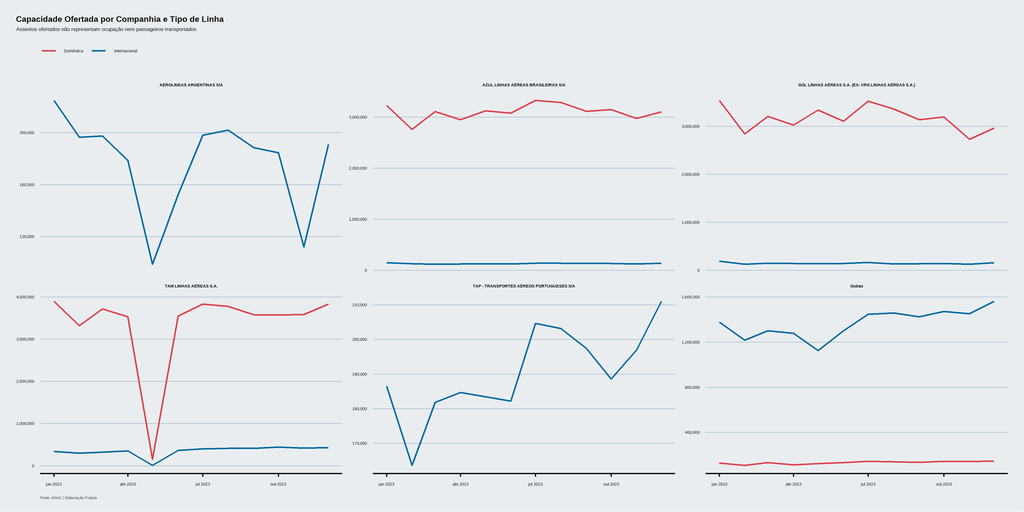

```r
voos |>
  filter(year(partida_prevista) == 2023, !is.na(empresa)) |>
  mutate(empresa_top = fct_lump_n(empresa, n = 5, w = assentos, other_level = "Outras")) |>
  summarise(assentos = sum(assentos, na.rm = TRUE),
            .by = c(mes, empresa_top, tipo_linha)) |>
  arrange(mes, empresa_top) |>
  ggplot(aes(mes, assentos, colour = tipo_linha)) +
    geom_line(linewidth = 0.8) +
    facet_wrap(~ empresa_top, scales = "free_y") +
    scale_y_continuous(labels = fmt_lab("number")) +
    scale_econ(aes = "colour", scheme = "web") +
    labs(title = "Capacidade Ofertada por Companhia e Tipo de Linha",
         subtitle = "Assentos ofertados não representam ocupação nem passageiros transportados",
         caption = "Fonte: ANAC | Elaboração Própria") +
    theme_econ_base()
```

## 11.2 Distância das Rotas por Status de Atraso

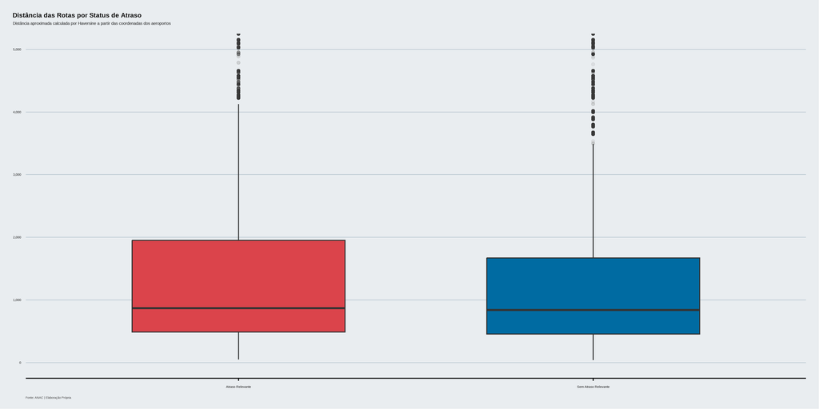

```r
voos_real |>
  filter(!is.na(longitude_origem), !is.na(latitude_origem),
         !is.na(longitude_destino), !is.na(latitude_destino)) |>
  mutate(dist_km = geosphere::distHaversine(cbind(longitude_origem, latitude_origem),
                                            cbind(longitude_destino, latitude_destino)) / 1000,
         grupo_atraso = if_else(atraso_relevante_chegada, "Atraso Relevante", "Sem Atraso Relevante")) |>
  ggplot(aes(grupo_atraso, dist_km, fill = grupo_atraso)) +
    geom_boxplot(outlier.alpha = 0.08, width = 0.6, show.legend = FALSE) +
    coord_cartesian(ylim = c(0, 5000)) +
    scale_y_continuous(labels = fmt_lab("number")) +
    scale_econ(aes = "fill", scheme = "web") +
    labs(title = "Distância das Rotas por Status de Atraso",
         subtitle = "Distância aproximada calculada por Haversine a partir das coordenadas dos aeroportos",
         caption = "Fonte: ANAC | Elaboração Própria") +
    theme_econ_base()
```

## 11.3 Perfil de Distância das Cinco Maiores Companhias

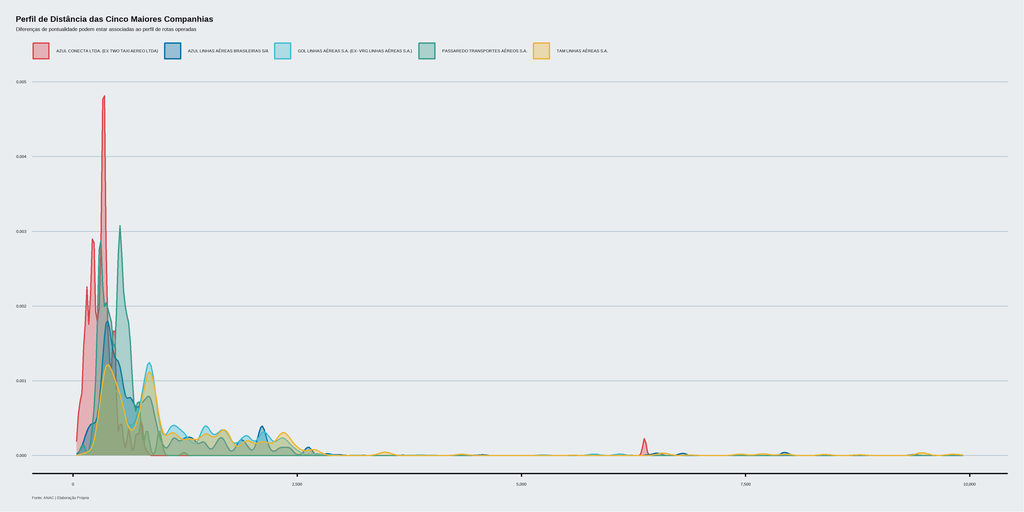

```r
voos_real |>
  drop_na(empresa) |>
  filter(!is.na(longitude_origem), !is.na(latitude_origem),
         !is.na(longitude_destino), !is.na(latitude_destino)) |>
  mutate(dist_km = geosphere::distHaversine(cbind(longitude_origem, latitude_origem),
                                            cbind(longitude_destino, latitude_destino)) / 1000,
         empresa_top = fct_lump_n(empresa, n = 5, other_level = "Outras")) |>
  filter(empresa_top != "Outras") |>
  ggplot(aes(dist_km, fill = empresa_top, colour = empresa_top)) +
    geom_density(alpha = 0.35) +
    scale_x_continuous(labels = fmt_lab("number")) +
    scale_econ(aes = "fill", scheme = "web") +
    scale_econ(aes = "colour", scheme = "web") +
    labs(title = "Perfil de Distância das Cinco Maiores Companhias",
         subtitle = "Diferenças de pontualidade podem estar associadas ao perfil de rotas operadas",
         caption = "Fonte: ANAC | Elaboração Própria") +
    theme_econ_base()
```

## 11.4 Validação da Chave da Frota

```r
tibble(Chave = c("planes$icao_tipo", "planes$modelo"),
       Modelos_Correspondentes = c(voos |>
                                     drop_na(modelo_equipamento) |>
                                     distinct(modelo_equipamento) |>
                                     filter(modelo_equipamento %in% planes$icao_tipo) |>
                                     nrow(),
                                   voos |>
                                     drop_na(modelo_equipamento) |>
                                     distinct(modelo_equipamento) |>
                                     filter(modelo_equipamento %in% planes$modelo) |>
                                     nrow()),
       Modelos_Testados = voos |> drop_na(modelo_equipamento) |> distinct(modelo_equipamento) |> nrow(),
       Voos_Correspondentes = c(sum(voos$modelo_equipamento %in% planes$icao_tipo, na.rm = TRUE),
                                sum(voos$modelo_equipamento %in% planes$modelo, na.rm = TRUE)),
       Voos_Testados = sum(!is.na(voos$modelo_equipamento))) |>
  mutate(Taxa_por_Modelo = Modelos_Correspondentes / Modelos_Testados,
         Taxa_por_Voo = Voos_Correspondentes / Voos_Testados) |>
  arrange(desc(Taxa_por_Voo)) |>
  gt() |>
    tab_header(title = md("**Validação da Chave da Frota**"),
               subtitle = "Compatibilidade entre modelo_equipamento dos voos e chaves possíveis da base planes") |>
    cols_label(Chave = "Chave",
               Modelos_Correspondentes = "Modelos Correspondentes",
               Modelos_Testados = "Modelos Testados",
               Voos_Correspondentes = "Voos Correspondentes",
               Voos_Testados = "Voos Testados",
               Taxa_por_Modelo = "Taxa por Modelo",
               Taxa_por_Voo = "Taxa por Voo") |>
    fmt_number(columns = c(Modelos_Correspondentes, Modelos_Testados,
                           Voos_Correspondentes, Voos_Testados),
               decimals = 0, sep_mark = ".", dec_mark = ",") |>
    fmt_percent(columns = c(Taxa_por_Modelo, Taxa_por_Voo),
                decimals = 1, dec_mark = ",", sep_mark = ".") |>
    cols_align(align = "left", columns = Chave) |>
    cols_align(align = "center",
               columns = c(Modelos_Correspondentes, Modelos_Testados,
                           Voos_Correspondentes, Voos_Testados,
                           Taxa_por_Modelo, Taxa_por_Voo)) |>
    tab_source_note(source_note = "Fonte: ANAC | Elaboração Própria") |>
    tab_options(heading.align = "left",
                column_labels.font.weight = "bold",
                column_labels.border.top.width = px(3),
                column_labels.border.top.color = "#E3120B",
                table.border.bottom.color = "black",
                table_body.hlines.color = "#ececec",
                table.border.top.style = "hidden")
```

**Validação da Chave da Frota**

Compatibilidade entre modelo_equipamento dos voos e chaves possíveis da base planes

| Chave | Modelos Correspondentes | Modelos Testados | Voos Correspondentes | Voos Testados | Taxa por Modelo | Taxa por Voo |
| --- | --- | --- | --- | --- | --- | --- |
| planes$icao_tipo | 31 | 62 | 610.397 | 958.566 | 50,0% | 63,7% |
| planes$modelo | 0 | 62 | 0 | 958.566 | 0,0% | 0,0% |

Fonte: ANAC | Elaboração Própria

## 11.5 Modelo de Equipamento e Desempenho Operacional

```r
voos |>
  drop_na(modelo_equipamento) |>
  summarise(voos = n(),
            voos_realizados = sum(voo_realizado, na.rm = TRUE),
            pct_atraso_relevante = mean(atraso_relevante_chegada, na.rm = TRUE),
            taxa_cancelamento = mean(cancelado, na.rm = TRUE),
            assentos_medios = mean(assentos, na.rm = TRUE),
            .by = modelo_equipamento) |>
  filter(voos >= 1000) |>
  arrange(desc(pct_atraso_relevante)) |>
  slice_head(n = 20) |>
  gt() |>
    tab_header(title = md("**Modelo de Equipamento e Desempenho**"),
               subtitle = "Associação por categoria de equipamento, não por aeronave individual") |>
    cols_label(modelo_equipamento = "Modelo",
               voos = "Voos",
               voos_realizados = "Voos Realizados",
               pct_atraso_relevante = "Atraso Relevante",
               taxa_cancelamento = "Cancelamento",
               assentos_medios = "Assentos Médios") |>
    fmt_number(columns = c(voos, voos_realizados, assentos_medios),
               decimals = 0, sep_mark = ".", dec_mark = ",") |>
    fmt_percent(columns = c(pct_atraso_relevante, taxa_cancelamento),
                decimals = 1, dec_mark = ",", sep_mark = ".") |>
    cols_align(align = "left", columns = modelo_equipamento) |>
    cols_align(align = "center",
               columns = c(voos, voos_realizados, pct_atraso_relevante,
                           taxa_cancelamento, assentos_medios)) |>
    tab_source_note(source_note = "Fonte: ANAC | Elaboração Própria") |>
    tab_options(heading.align = "left",
                column_labels.font.weight = "bold",
                column_labels.border.top.width = px(3),
                column_labels.border.top.color = "#E3120B",
                table.border.bottom.color = "black",
                table_body.hlines.color = "#ececec",
                table.border.top.style = "hidden")
```

**Modelo de Equipamento e Desempenho**

Associação por categoria de equipamento, não por aeronave individual

| Modelo | Voos | Voos Realizados | Atraso Relevante | Cancelamento | Assentos Médios |
| --- | --- | --- | --- | --- | --- |
| B744 | 4.388 | 3.220 | 59,0% | 26,5% | 2 |
| B748 | 1.988 | 1.700 | 51,0% | 14,5% | 135 |
| AT45 | 3.961 | 3.168 | 50,5% | 20,0% | 46 |
| A330 | 1.769 | 1.181 | 41,9% | 33,2% | 292 |
| B73Y | 3.020 | 2.696 | 38,4% | 10,7% | 0 |
| B763 | 14.008 | 12.665 | 36,7% | 9,6% | 30 |
| A332 | 8.077 | 4.035 | 34,8% | 50,0% | 193 |
| A359 | 5.876 | 3.343 | 33,0% | 43,1% | 338 |
| B77L | 10.782 | 3.617 | 30,5% | 66,5% | 16 |
| B734 | 5.819 | 5.411 | 29,7% | 7,0% | 1 |
| A339 | 8.238 | 8.137 | 28,6% | 1,2% | 298 |
| B722 | 2.219 | 1.938 | 28,4% | 12,7% | 0 |
| B789 | 8.688 | 8.572 | 28,4% | 1,3% | 295 |
| B77W | 8.659 | 8.547 | 27,8% | 1,3% | 372 |
| B788 | 4.764 | 4.573 | 27,7% | 4,0% | 260 |
| AT72 | 17.558 | 16.095 | 27,0% | 8,3% | 68 |
| B77F | 1.179 | 1.001 | 26,0% | 15,1% | 0 |
| B772 | 3.383 | 3.196 | 25,6% | 5,5% | 292 |
| B773 | 2.293 | 2.245 | 25,3% | 2,1% | 355 |
| A333 | 1.392 | 1.380 | 25,3% | 0,9% | 283 |

Fonte: ANAC | Elaboração Própria

## 11.6 Idade Aproximada do Equipamento e Desempenho

```r
voos |>
  left_join(planes |>
              drop_na(icao_tipo) |>
              summarise(ano_medio = mean(ano_fabricacao, na.rm = TRUE),
                        cobertura_ano = mean(!is.na(ano_fabricacao)),
                        aeronaves = n_distinct(matricula, na.rm = TRUE),
                        .by = icao_tipo) |>
              rename(modelo_equipamento = icao_tipo),
            by = "modelo_equipamento") |>
  mutate(idade_media_tipo = 2023 - ano_medio,
         faixa_idade = cut(idade_media_tipo,
                           breaks = c(0, 5, 10, 20, 40, Inf),
                           labels = c("0-5", "6-10", "11-20", "21-40", "40+"))) |>
  filter(!is.na(faixa_idade), cobertura_ano >= 0.5) |>
  summarise(voos = n(),
            pct_atraso_relevante = mean(atraso_relevante_chegada, na.rm = TRUE),
            taxa_cancelamento = mean(cancelado, na.rm = TRUE),
            .by = faixa_idade) |>
  arrange(faixa_idade) |>
  gt() |>
    tab_header(title = md("**Idade Aproximada do Equipamento e Desempenho**"),
               subtitle = "Análise exploratória condicionada à cobertura de ano de fabricação") |>
    cols_label(faixa_idade = "Faixa de Idade",
               voos = "Voos",
               pct_atraso_relevante = "Atraso Relevante",
               taxa_cancelamento = "Cancelamento") |>
    fmt_number(columns = voos, decimals = 0, sep_mark = ".", dec_mark = ",") |>
    fmt_percent(columns = c(pct_atraso_relevante, taxa_cancelamento),
                decimals = 1, dec_mark = ",", sep_mark = ".") |>
    cols_align(align = "center",
               columns = c(faixa_idade, voos, pct_atraso_relevante, taxa_cancelamento)) |>
    tab_source_note(source_note = "Fonte: ANAC | Elaboração Própria") |>
    tab_options(heading.align = "left",
                column_labels.font.weight = "bold",
                column_labels.border.top.width = px(3),
                column_labels.border.top.color = "#E3120B",
                table.border.bottom.color = "black",
                table_body.hlines.color = "#ececec",
                table.border.top.style = "hidden")
```

**Idade Aproximada do Equipamento e Desempenho**

Análise exploratória condicionada à cobertura de ano de fabricação

| Faixa de Idade | Voos | Atraso Relevante | Cancelamento |
| --- | --- | --- | --- |
| 0-5 | 82.906 | 22,9% | 1,5% |
| 6-10 | 63.442 | 20,6% | 5,1% |
| 11-20 | 221.901 | 21,6% | 6,0% |
| 21-40 | 235.058 | 20,0% | 5,8% |
| 40+ | 2.690 | 28,4% | 10,5% |

Fonte: ANAC | Elaboração Própria

# 12 Tópico : Modelagem de Fatores Associados a Atrasos (Random Forest)

## 12.1 Escolha do Problema de Modelagem

```r
tribble(
  ~ Problema,                       ~ Classe,                                ~ Variaveis_Disponiveis,                                                            ~ Clareza_Interpretativa,                                  ~ Decisao,
  "Atraso relevante de chegada",    "Mais informativa entre voos realizados", "Empresa, aeroporto, rota, turno, mês, tipo de linha, assentos e conectividade",   "Interpretação via importância de variáveis e PDPs",       "Modelo principal",
  "Cancelamento",                   "Possivelmente mais raro",                "Empresa, aeroporto, mês, rota, tipo de linha e assentos previstos",               "Boa, mas pode sofrer com desbalanceamento",               "Análise descritiva principal e possível extensão"
) |>
  gt() |>
  tab_header(title = md("**Escolha do Problema de Modelagem**"),
             subtitle = "A modelagem principal usa atraso relevante de chegada como alvo") |>
  cols_label(Variaveis_Disponiveis = "Variáveis Disponíveis",
             Clareza_Interpretativa = "Clareza Interpretativa") |>
  cols_align(align = "left",
             columns = c(Problema, Classe, Variaveis_Disponiveis, Clareza_Interpretativa, Decisao)) |>
  tab_source_note(source_note = "Fonte: ANAC | Elaboração Própria") |>
  tab_options(heading.align = "left",
              column_labels.font.weight = "bold",
              column_labels.border.top.width = px(3),
              column_labels.border.top.color = "#E3120B",
              table.border.bottom.color = "black",
              table_body.hlines.color = "#ececec",
              table.border.top.style = "hidden")
```

**Escolha do Problema de Modelagem**

A modelagem principal usa atraso relevante de chegada como alvo

| Problema | Classe | Variáveis Disponíveis | Clareza Interpretativa | Decisao |
| --- | --- | --- | --- | --- |
| Atraso relevante de chegada | Mais informativa entre voos realizados | Empresa, aeroporto, rota, turno, mês, tipo de linha, assentos e conectividade | Interpretação via importância de variáveis e PDPs | Modelo principal |
| Cancelamento | Possivelmente mais raro | Empresa, aeroporto, mês, rota, tipo de linha e assentos previstos | Boa, mas pode sofrer com desbalanceamento | Análise descritiva principal e possível extensão |

Fonte: ANAC | Elaboração Própria

## 12.2 Separação de Treino e Teste (Split Temporal)

```r
db_mod <- voos_real |>
  filter(year(partida_prevista) == 2023) |>
  left_join(ap_perf |> select(origem_icao, destinos_origem = destinos_distintos, partidas_origem = partidas),
            by = "origem_icao") |>
  mutate(alvo_atraso = factor(if_else(atraso_relevante_chegada, "atraso", "sem_atraso"),
                        levels = c("atraso", "sem_atraso")),
         empresa = as.factor(empresa),
         origem_icao = as.factor(origem_icao),
         destino_icao = as.factor(destino_icao),
         tipo_linha = as.factor(tipo_linha),
         turno = as.factor(turno),
         mes_nome = as.factor(mes_nome),
        dia_semana = as.factor(dia_semana)) |>
  select(alvo_atraso, partida_prevista, empresa, origem_icao, destino_icao,
         tipo_linha, turno, mes_nome, dia_semana, assentos, destinos_origem, partidas_origem) |>
  drop_na()

trn <- db_mod |> filter(partida_prevista < ymd("2023-10-01"))

tst <- db_mod |> filter(partida_prevista >= ymd("2023-10-01"))

bind_rows(trn |> summarise(Amostra = "Treino",
                           Periodo = paste(format(min(partida_prevista), "%d/%m/%Y"),
                                           format(max(partida_prevista), "%d/%m/%Y"),
                                           sep = " a "),
                           Observacoes = n(),
                           Taxa_Alvo = mean(alvo_atraso == "atraso")),
          tst |> summarise(Amostra = "Teste",
                           Periodo = paste(format(min(partida_prevista), "%d/%m/%Y"),
                                           format(max(partida_prevista), "%d/%m/%Y"),
                                           sep = " a "),
                           Observacoes = n(),
                           Taxa_Alvo = mean(alvo_atraso == "atraso"))) |>
  gt() |>
    tab_header(title = md("**Separação Temporal de Treino e Teste**"),
               subtitle = "Treino até setembro; teste de outubro em diante") |>
    cols_label(Periodo = "Período",
               Observacoes = "Observações",
               Taxa_Alvo = "Taxa do Alvo") |>
    fmt_number(columns = Observacoes, decimals = 0, sep_mark = ".", dec_mark = ",") |>
    fmt_percent(columns = Taxa_Alvo, decimals = 1, dec_mark = ",", sep_mark = ".") |>
    cols_align(align = "left", columns = c(Amostra, Periodo)) |>
    cols_align(align = "center", columns = c(Observacoes, Taxa_Alvo)) |>
    tab_source_note(source_note = "Fonte: ANAC | Elaboração Própria") |>
    tab_options(heading.align = "left",
                column_labels.font.weight = "bold",
                column_labels.border.top.width = px(3),
                column_labels.border.top.color = "#E3120B",
                table.border.bottom.color = "black",
                table_body.hlines.color = "#ececec",
                table.border.top.style = "hidden")
```

**Separação Temporal de Treino e Teste**

Treino até setembro; teste de outubro em diante

| Amostra | Período | Observações | Taxa do Alvo |
| --- | --- | --- | --- |
| Treino | 01/01/2023 a 30/09/2023 | 651.008 | 18,0% |
| Teste | 01/10/2023 a 31/12/2023 | 220.871 | 21,9% |

Fonte: ANAC | Elaboração Própria

## 12.3 Modelo Baseline: Classe Majoritária

```r
classe_maj <- trn |>
  count(alvo_atraso) |>
  slice_max(order_by = n, n = 1, with_ties = FALSE) |>
  pull(alvo_atraso) |>
  as.character()

metricas_bin <- metric_set(accuracy, kap, sens, yardstick::spec)

tst |>
  select(alvo_atraso) |>
  mutate(.pred_class = factor(classe_maj, levels = levels(alvo_atraso))) |>
  metricas_bin(truth = alvo_atraso, estimate = .pred_class) |>
  gt() |>
    tab_header(title = md("**Baseline de Classificação**"),
               subtitle = "Regra simples: sempre prever a classe majoritária do treino") |>
    cols_label(.metric = "Métrica",
               .estimator = "Estimador",
               .estimate = "Estimativa") |>
    fmt_number(columns = .estimate, decimals = 3, dec_mark = ",", sep_mark = ".") |>
    cols_align(align = "left", columns = .metric) |>
    cols_align(align = "center", columns = c(.estimator, .estimate)) |>
    tab_source_note(source_note = "Fonte: ANAC | Elaboração Própria") |>
    tab_options(heading.align = "left",
                column_labels.font.weight = "bold",
                column_labels.border.top.width = px(3),
                column_labels.border.top.color = "#E3120B",
                table.border.bottom.color = "black",
                table_body.hlines.color = "#ececec",
                table.border.top.style = "hidden")
```

**Baseline de Classificação**

Regra simples: sempre prever a classe majoritária do treino

| Métrica | Estimador | Estimativa |
| --- | --- | --- |
| accuracy | binary | 0,781 |
| kap | binary | 0,000 |
| sens | binary | 0,000 |
| spec | binary | 1,000 |

Fonte: ANAC | Elaboração Própria

## 12.4 Modelo Principal: Random Forest

```r
fit_rf <- workflow() |>
  add_recipe(recipe(alvo_atraso ~ empresa + origem_icao + destino_icao + tipo_linha + turno +
                      mes_nome + dia_semana + assentos + destinos_origem + partidas_origem, data = trn) |>
               step_other(all_nominal_predictors(), threshold = 0.01, other = "Outros") |>
               step_zv(all_predictors())) |>
  add_model(rand_forest(trees = 500) |>
              set_engine("ranger", importance= "impurity")|>
              set_mode("classification")) |>
  fit(data = trn)

pred_rf <- predict(fit_rf, new_data = tst, type = "prob") |>
  bind_cols(predict(fit_rf, new_data = tst, type = "class")) |>
  bind_cols(tst |> select(alvo_atraso))

metricas_bin(pred_rf, truth = alvo_atraso, estimate = .pred_class) |>
  bind_rows(roc_auc(pred_rf, truth = alvo_atraso, .pred_atraso)) |>
  gt() |>
    tab_header(title = md("**Performance do Modelo Random Forest**"),
               subtitle = "Avaliação temporal no conjunto de teste (ranger, 500 árvores)") |>
    cols_label(.metric = "Métrica",
               .estimator = "Estimador",
               .estimate = "Estimativa") |>
    fmt_number(columns = .estimate, decimals = 3, dec_mark = ",", sep_mark = ".") |>
    cols_align(align = "left", columns = .metric) |>
    cols_align(align = "center", columns = c(.estimator, .estimate)) |>
    gt_color_rows(columns = .estimate,
                  palette = c("#E64E53", "#ffffff", "#3D89C3"),
                  domain = c(0, 1)) |>
    tab_source_note(source_note = "Fonte: ANAC | Elaboração Própria") |>
    tab_options(heading.align = "left",
                column_labels.font.weight = "bold",
                column_labels.border.top.width = px(3),
                column_labels.border.top.color = "#E3120B",
                table.border.bottom.color = "black",
                table_body.hlines.color = "#ececec",
                table.border.top.style = "hidden")
```

**Performance do Modelo Random Forest**

Avaliação temporal no conjunto de teste (ranger, 500 árvores)

| Métrica | Estimador | Estimativa |
| --- | --- | --- |
| accuracy | binary | 0,786 |
| kap | binary | 0,082 |
| sens | binary | 0,070 |
| spec | binary | 0,986 |
| roc_auc | binary | 0,662 |

Fonte: ANAC | Elaboração Própria

## 12.5 Matriz de Confusão

```r
conf_mat(pred_rf, truth = alvo_atraso, estimate = .pred_class)$table |>
  as.data.frame() |>
  gt() |>
    tab_header(title = md("**Matriz de Confusão**"),
               subtitle = "Classificação do atraso relevante no conjunto de teste (Random Forest)") |>
    cols_label(Prediction = "Predito",
               Truth = "Observado",
               Freq = "Frequência") |>
    fmt_number(columns = Freq, decimals = 0, sep_mark = ".", dec_mark = ",") |>
    cols_align(align = "center", columns = c(Prediction, Truth, Freq)) |>
    tab_source_note(source_note = "Fonte: ANAC | Elaboração Própria") |>
    tab_options(heading.align = "left",
                column_labels.font.weight = "bold",
                column_labels.border.top.width = px(3),
                column_labels.border.top.color = "#E3120B",
                table.border.bottom.color = "black",
                table_body.hlines.color = "#ececec",
                table.border.top.style = "hidden")
```

**Matriz de Confusão**

Classificação do atraso relevante no conjunto de teste (Random Forest)

| Predito | Observado | Frequência |
| --- | --- | --- |
| atraso | atraso | 3.375 |
| sem_atraso | atraso | 44.934 |
| atraso | sem_atraso | 2.384 |
| sem_atraso | sem_atraso | 170.178 |

Fonte: ANAC | Elaboração Própria

## 12.6 Principais Variáveis Associadas ao Atraso Relevante

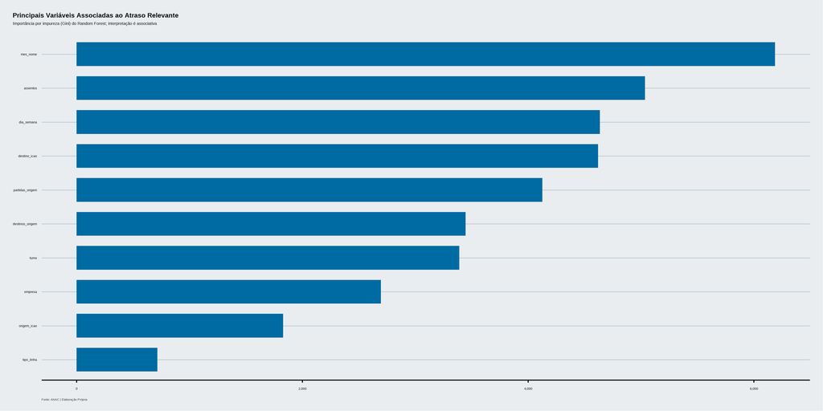

```r
extract_fit_parsnip(fit_rf)$fit$variable.importance |>
  enframe(name = "term", value = "importancia") |>
  mutate(term = as.character(term)) |>
  slice_max(order_by = importancia, n = 20) |>
  mutate(term = fct_reorder(term, importancia)) |>
  ggplot(aes(importancia, term)) +
    geom_col(fill = pal["blue1"], width = 0.7) +
    scale_x_continuous(labels = fmt_lab("number")) +
    labs(title = "Principais Variáveis Associadas ao Atraso Relevante",
         subtitle = "Importância por impureza (Gini) do Random Forest; interpretação é associativa",
         caption = "Fonte: ANAC | Elaboração Própria") +
    theme_econ_base()
```

# 13 Tópico : Classificação de Grupos de Aeroportos (K-Means)

## 13.1 Seleção de Atributos (Volume, Conectividade e Atraso de Partida)

```r
db_ap <- voos |>
  drop_na(origem_icao, destino_icao) |>
  summarise(volume = n(),
            conectividade = n_distinct(destino_icao),
            atraso_medio = mean(atraso_partida_min, na.rm = TRUE),
            .by = c(origem_icao, nome_origem)) |>
  drop_na()

X_ap <- db_ap |>
  select(volume, conectividade, atraso_medio) |>
  scale()

rownames(X_ap) <- db_ap$origem_icao
```

## 13.2 Clusterização e Perfilamento dos Grupos de Aeroportos

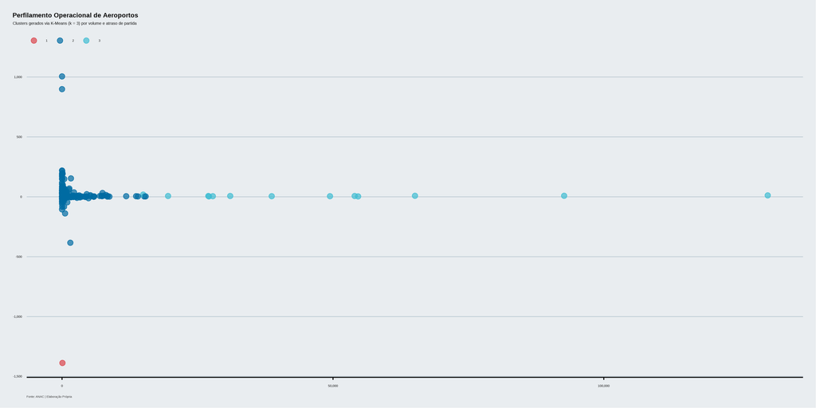

```r
km_res <- kmeans(X_ap, centers = 3, nstart = 20)

db_ap_clust <- db_ap |>
  mutate(cluster = as.factor(km_res$cluster)) |>
  left_join(airports, by = c("origem_icao" = "icao")) |>
  drop_na(longitude, latitude)

db_ap_clust |>
  ggplot(aes(volume, atraso_medio, colour = cluster)) +
    geom_point(size = 3, alpha = 0.7) +
    scale_x_continuous(labels = fmt_lab("number")) +
    scale_y_continuous(labels = fmt_lab("number")) +
    scale_econ(aes = "colour", scheme = "web") +
    labs(title = "Perfilamento Operacional de Aeroportos",
         subtitle = "Clusters gerados via K-Means (k = 3) por volume e atraso de partida",
         colour = "Cluster",
         caption = "Fonte: ANAC | Elaboração Própria") +
    theme_econ_base()
```

## 13.3 Distribuição Geográfica dos Clusters Operacionais

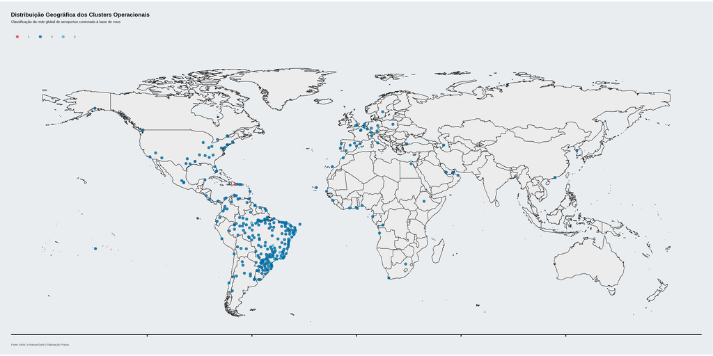

```r
ne_countries(scale = "medium", returnclass = "sf") |>
  filter(name_long != "Antarctica") |>
  ggplot() +
    geom_sf(fill = "#ececec", colour = "gray9", linewidth = 0.3) +
    geom_sf(data = db_ap_clust |>
              st_as_sf(coords = c("longitude", "latitude"), crs = 4326),
            aes(colour = cluster), size = 1.5, alpha = 0.8) +
    scale_econ(aes = "colour", scheme = "web") +
    labs(title = "Distribuição Geográfica dos Clusters Operacionais",
         subtitle = "Classificação da rede global de aeroportos conectada à base de voos",
         colour = "Cluster",
         caption = "Fonte: ANAC e Natural Earth | Elaboração Própria") +
    theme_econ_base() +
    theme(axis.text = element_blank(),
          axis.ticks = element_blank(),
          panel.grid = element_blank())
```

# 14 Tópico : Síntese Executiva

## 14.1 Tabela Final de KPIs por Companhia

```r
voos |>
  drop_na(empresa) |>
  summarise(voos = n(),
            voos_realizados = sum(voo_realizado, na.rm = TRUE),
            assentos = sum(assentos, na.rm = TRUE),
            atraso_medio_chegada = mean(atraso_chegada_min[voo_realizado], na.rm = TRUE),
            pct_atraso_relevante = mean(atraso_relevante_chegada, na.rm = TRUE),
            taxa_cancelamento = mean(cancelado, na.rm = TRUE),
            aeroportos_origem = n_distinct(origem_icao, na.rm = TRUE),
            rotas = n_distinct(rota, na.rm = TRUE),
            .by = empresa) |>
  filter(voos >= 5000) |>
  arrange(desc(pct_atraso_relevante)) |>
  slice_head(n = 15) |>
  gt() |>
    tab_header(title = md("**Síntese Executiva por Companhia**"),
               subtitle = "Volume, atraso, cancelamento, capacidade e contexto de malha") |>
    cols_label(empresa = "Companhia",
               voos = "Voos",
               voos_realizados = "Realizados",
               assentos = "Assentos",
               atraso_medio_chegada = "Atraso Médio",
               pct_atraso_relevante = "Atraso Relevante",
               taxa_cancelamento = "Cancelamento",
               aeroportos_origem = "Origens",
               rotas = "Rotas") |>
    fmt_number(columns = c(voos, voos_realizados, assentos, aeroportos_origem, rotas),
               decimals = 0, sep_mark = ".", dec_mark = ",") |>
    fmt_number(columns = atraso_medio_chegada,
               decimals = 1, dec_mark = ",", sep_mark = ".") |>
    fmt_percent(columns = c(pct_atraso_relevante, taxa_cancelamento),
                decimals = 1, dec_mark = ",", sep_mark = ".") |>
    cols_align(align = "left", columns = empresa) |>
    cols_align(align = "center",
               columns = c(voos, voos_realizados, assentos, atraso_medio_chegada,
                           pct_atraso_relevante, taxa_cancelamento,
                           aeroportos_origem, rotas)) |>
    gt_color_rows(columns = pct_atraso_relevante, palette = c("#ffffff", "#E64E53")) |>
    tab_source_note(source_note = "Fonte: ANAC | Elaboração Própria") |>
    tab_options(heading.align = "left",
                column_labels.font.weight = "bold",
                column_labels.border.top.width = px(3),
                column_labels.border.top.color = "#E3120B",
                table.border.bottom.color = "black",
                table_body.hlines.color = "#ececec",
                table.border.top.style = "hidden")
```

**Síntese Executiva por Companhia**

Volume, atraso, cancelamento, capacidade e contexto de malha

| Companhia | Voos | Realizados | Assentos | Atraso Médio | Atraso Relevante | Cancelamento | Origens | Rotas |
| --- | --- | --- | --- | --- | --- | --- | --- | --- |
| SIDERAL LINHAS AÉREAS LTDA. | 8.031 | 7.373 | 53.190 | 14,5 | 34,0% | 8,2% | 41 | 193 |
| TAP - TRANSPORTES AÉREOS PORTUGUESES S/A | 7.704 | 7.648 | 2.127.038 | 4,6 | 28,8% | 0,7% | 17 | 42 |
| PASSAREDO TRANSPORTES AÉREOS S.A. | 17.992 | 16.610 | 1.207.943 | 17,8 | 27,2% | 7,7% | 48 | 210 |
| QATAR AIRWAYS GROUP | 8.643 | 2.356 | 586.876 | 25,6 | 26,9% | 72,7% | 42 | 119 |
| LATAM AIRLINES GROUP (EX - LAN AIRLINES S/A) | 6.932 | 6.806 | 1.497.130 | 6,2 | 25,0% | 1,8% | 19 | 49 |
| AEROLINEAS ARGENTINAS S/A | 13.011 | 7.718 | 2.335.544 | 5,4 | 24,6% | 40,7% | 38 | 96 |
| AZUL CONECTA LTDA. (EX TWO TAXI AEREO LTDA) | 25.734 | 20.257 | 200.989 | 9,1 | 22,2% | 21,3% | 132 | 434 |
| GOL LINHAS AÉREAS S.A. (EX- VRG LINHAS AÉREAS S.A.) | 233.354 | 227.413 | 40.893.782 | 2,9 | 21,7% | 2,5% | 103 | 875 |
| TAM LINHAS AÉREAS S.A. | 240.095 | 235.708 | 45.077.713 | 3,3 | 17,9% | 1,8% | 91 | 686 |
| AZUL LINHAS AÉREAS BRASILEIRAS S/A | 304.131 | 294.884 | 39.147.133 | 0,9 | 13,6% | 3,0% | 134 | 1.221 |
| COMPAÑIA PANAMEÑA DE AVIACION S.A. (COPA AIRLINES) | 8.067 | 7.623 | 1.314.788 | −29,2 | 8,0% | 5,5% | 8 | 14 |

Fonte: ANAC | Elaboração Própria

# 15 Conclusão

A análise da operação aérea brasileira em 2023 revela uma malha de grande escala, com quase 960 mil voos, 118 companhias e 389 aeroportos de origem. Apesar dessa dimensão, os resultados mostram uma operação heterogênea, o que reforça a necessidade de avaliar o desempenho por recortes específicos, e não apenas pela média geral. Os dois desfechos estudados apresentam dinâmicas próprias: o atraso relevante atinge 18,9% dos voos realizados, enquanto o cancelamento, mais severo, fica em 5,4%, com padrões de sazonalidade e geografia distintos.

Quanto ao atraso, identificamos três padrões principais. O primeiro é temporal: o desempenho piora ao longo do dia operacional, com voos noturnos superando 20% de atraso relevante, contra aproximadamente 15% na madrugada e na manhã. Esse comportamento se intensifica no último trimestre, com pico próximo de 25% em outubro, sugerindo propagação de atrasos pela malha. O segundo padrão é estrutural: o eixo paulista, formado por Guarulhos, Congonhas e Viracopos, além da rota entre Congonhas e Santos Dumont, tem peso desproporcional no resultado agregado por causa do alto volume de voos, mesmo quando as taxas não são muito superiores à média. O terceiro ponto é que a distância da rota, isoladamente, não separa de forma clara voos atrasados e pontuais, indicando que o atraso é um fenômeno multifatorial.

O cancelamento segue uma lógica diferente. As maiores taxas estão em aeroportos internacionais de menor volume, como Madrid, Quito e Doha, e em companhias internacionais e algumas cargueiras, com Ibéria e Qatar acima de 70%. Em contraste, os grandes hubs domésticos apresentam regularidade relativamente maior. A comparação entre hubs e demais aeroportos reforça essa diferença: o atraso relevante é quase idêntico, com 19,0% nos hubs e 18,6% nos demais aeroportos, mas a taxa de cancelamento dos aeroportos menos centrais, de 12,2%, é cerca de três vezes a dos hubs, de 4,1%. A análise de frota, condicionada à cobertura parcial da chave `icao_tipo`, de 63,7%, tem caráter exploratório e não evidencia uma relação linear simples entre idade do equipamento e desempenho operacional.

A avaliação de desempenho aéreo não pode depender de um único indicador. Ela exige combinar volume, capacidade, atraso, cancelamento e contexto de malha. As principais limitações do estudo são a ausência de justificativas completas para os desfechos, o que impede inferência causal, a presença de registros com horários inconsistentes e a cobertura parcial da base de frota. Essas limitações delimitam o alcance das conclusões e apontam extensões naturais para o trabalho, como incorporar dados meteorológicos e de tráfego, modelar a propagação de atrasos, tratar o desbalanceamento da variável-alvo e analisar o cancelamento como um desfecho próprio.